# Polytropic ideal reactors - Hydrolysis of Ethylene Oxide (EO) to Ethylene Glycol (EG)

### Chemical Reaction Engineering 3 - Assignment 3

Group 4

- Julian Stierstorfer (1160552)
- Kartik Nair (3097841)
- Sanskar Nashier (3104558)

## 1. Introduction

The hydrolysis of ethylene oxide ($\mathrm{EO}$) to ethylene glycol ($\mathrm{EG}$) is an industrially relevant liquid-phase reaction carried out in a water-based solvent system. Ethylene oxide is an important chemical intermediate and is mainly used for the production of ethylene glycol and other oxygen-containing products. Ethylene glycol is widely applied as a raw material for polyester production and as a component in antifreeze and coolant formulations.

The modelling approach used in this assignment is based on the derivation of a discontinuous stirred tank reactor model first. In the DSTR, ideal mixing is assumed, so concentrations and temperature depend only on time. In a second step, this model is adapted to a plug-flow tubular reactor by applying a time-space transformation. The temporal coordinate of the DSTR is transferred to the axial coordinate of the PFTR by using the local residence time $\tau(z)$. For the full reactor length $L_\mathrm{R}$, the residence time is given by $\tau$.

\begin{equation} \tau(z) = \frac{z}{u} \qquad \text{and} \qquad \tau = \frac{L_\mathrm{R}}{u} \tag{2} \end{equation}

Thus, the time-dependent reactor behaviour is transformed into spatial concentration and temperature profiles along the reactor length.

Mathematically, the main challenge is the coupling of mass and energy balances. The mass balances describe the consumption of $\mathrm{EO}$ and the formation of $\mathrm{EG}$, while the energy balance accounts for heat generation by the exothermic reaction and heat exchange with the reactor wall. Since the reaction rate depends on temperature and the temperature depends on the heat released by the reaction, both balances have to be solved simultaneously.

To evaluate the sensitivity of the reaction system, selected operating and design parameters are varied. These include the inlet temperature, wall temperature, inlet concentration, flow velocity, reactor length, reactor diameter and heat-transfer coefficient. The resulting effects on conversion, outlet temperature and maximum reactor temperature are analysed. Finally, the numerical results are compared with literature-based expectations and limiting cases, such as isothermal and adiabatic reactor behaviour, to assess the plausibility of the implemented model.

## 2. Theoretical Background - discontinuous stirred tank reactor (DSTR) and plug-flow tubular reactor (PFTR)

### 2.1 Mass and energy balances

The reactor model is based on coupled component and energy balances. The component balances describe the change of the concentrations due to chemical reaction, while the energy balance describes the temperature change caused by reaction heat and heat transfer through the reactor wall. For the hydrolysis of ethylene oxide, the reaction is treated as a single irreversible reaction:

\begin{equation} \mathrm{EO} + \mathrm{H_2O} \rightarrow \mathrm{EG} \tag{3} \end{equation}

In the water-based solvent system, water is present in large excess. Therefore, the reaction rate can be formulated as  
pseudo-first order with respect to $\mathrm{EO}$:

\begin{equation} r = k(T)c_\mathrm{EO} \tag{4} \end{equation}

The temperature dependence of the reaction rate constant is described by an Arrhenius expression:

\begin{equation} k(T) = k_0 \exp\left(-\frac{E_\mathrm{A}}{RT}\right) \tag{5} \end{equation}

### 2.2 DSTR model

In the discontinuous stirred tank reactor, ideal mixing is assumed. Thus, the concentrations and temperature are spatially uniform inside the reactor and only change with time. Since there is no inlet or outlet stream during the reaction, the component balance only contains the reaction term.

For a general reaction network, the component balance is:

\begin{equation} \frac{dc_i}{dt} = \sum_{j=1}^{M} \nu_{i,j} r_j \tag{6} \end{equation}

For the single hydrolysis reaction, this gives:

\begin{equation} \frac{dc_\mathrm{EO}}{dt} = -r \tag{7} \end{equation}

\begin{equation} \frac{dc_\mathrm{EG}}{dt} = r \tag{8} \end{equation}

The energy balance contains heat generation by the exothermic reaction and heat exchange with the reactor wall:

\begin{equation} \rho c_p \frac{dT}{dt} = -\Delta_\mathrm{R}H \, r - \frac{h_\mathrm{W} A_\mathrm{W}}{V_\mathrm{R}} \left(T - T_\mathrm{K}\right) \tag{9} \end{equation}

The first term on the right-hand side describes the heat released by reaction. Since $\Delta_\mathrm{R}H < 0$, the term $-\Delta_\mathrm{R}H r$ is positive and increases the reactor temperature. The second term describes heat removal if $T > T_\mathrm{K}$.

The DSTR model is solved as an initial value problem with:

\begin{equation} c_\mathrm{EO}(t=0)=c_{\mathrm{EO},0}, \qquad c_\mathrm{EG}(t=0)=0, \qquad T(t=0)=T_0 \tag{10} \end{equation}

### 2.3 PFTR model

[figure not shown]

Figure 1: Representation of an ideal tube [1].

In the plug-flow tubular reactor, ideal radial mixing and no axial backmixing are assumed. Therefore, the variables are not functions of time, but of the axial coordinate $z$ for the steady-state case. The transformation from the DSTR model to the PFTR model is based on the local residence time:

\begin{equation} \tau(z)=\frac{z}{u} \tag{11} \end{equation}

For a constant flow velocity $u$, the time derivative of the DSTR model can therefore be transferred to an axial derivative according to:

\begin{equation} \frac{d}{dt} \rightarrow u\frac{d}{dz} \tag{12} \end{equation}

The general steady-state component balance of the PFTR is:

\begin{equation} u\frac{dc_i}{dz} = \sum_{j=1}^{M} \nu_{i,j} r_j \tag{13} \end{equation}

For the hydrolysis reaction, the component balances become:

\begin{equation} u\frac{dc_\mathrm{EO}}{dz} = -r \tag{14} \end{equation}

\begin{equation} u\frac{dc_\mathrm{EG}}{dz} = r \tag{15} \end{equation}

The corresponding energy balance is:

\begin{equation} u \rho c_p \frac{dT}{dz} = -\Delta_\mathrm{R}H \, r - \frac{4h_\mathrm{W}}{d_\mathrm{R}} \left(T - T_\mathrm{K}\right) \tag{16} \end{equation}

The heat-transfer term differs from the DSTR formulation since the tubular reactor geometry is expressed  
by the surface-to-volume ratio of a tube $\left(\frac{A_\mathrm{W}}{V_\mathrm{R}}=\frac{4}{d_\mathrm{R}}\right)$.

The PFTR model is solved as an initial value problem along the reactor length with inlet boundary conditions:

\begin{equation} c_\mathrm{EO}(z=0)=c_{\mathrm{EO},e}, \qquad c_\mathrm{EG}(z=0)=0, \qquad T(z=0)=T_e \tag{17} \end{equation}

### 2.4 Dimensionless mass and energy balances of the PFTR

To investigate the influence of heat removal, the PFTR model is also formulated in dimensionless form. This allows a direct comparison between adiabatic, polytropic and isothermal reactor operation.

The axial coordinate is normalized with the reactor length:

\begin{equation} \zeta = \frac{z}{L_\mathrm{R}} \tag{18} \end{equation}

The residence time of the reactor is defined as:

\begin{equation} \tau = \frac{L_\mathrm{R}}{u} \tag{19} \end{equation}

The concentrations are normalized with the inlet concentration of $\mathrm{EO}$:

\begin{equation} f_i = \frac{c_i}{c_{\mathrm{EO},in}} \tag{20} \end{equation}

For the reactants and products used in this work, this gives:

\begin{equation} f_\mathrm{EO} = \frac{c_\mathrm{EO}}{c_{\mathrm{EO},in}} \qquad \text{and} \qquad f_\mathrm{EG} = \frac{c_\mathrm{EG}}{c_{\mathrm{EO},in}} \tag{21} \end{equation}

The temperature of the reactor and the wall temperature are normalized with the inlet temperature:

\begin{equation} \vartheta = \frac{T}{T_\mathrm{in}} \qquad \text{and} \qquad \vartheta_\mathrm{wall} = \frac{T_\mathrm{wall}}{T_\mathrm{in}} \tag{22} \end{equation}

The dimensionless reaction rate is referred to the inlet reaction rate:

\begin{equation} \frac{r}{r_\mathrm{in}} = \frac{k(T)c_\mathrm{EO}}{k(T_\mathrm{in})c_{\mathrm{EO},in}} \tag{23} \end{equation}

For first-order hydrolysis of $\mathrm{EO}$, this becomes:

\begin{equation} \frac{r}{r_\mathrm{in}} = \exp\left[ \gamma \left( 1-\frac{1}{\vartheta} \right) \right] f_\mathrm{EO} \tag{24} \end{equation}

The Arrhenius number describes the temperature sensitivity of the reaction rate:

\begin{equation} \gamma = \frac{E_\mathrm{A}}{R T_\mathrm{in}} \tag{25} \end{equation}

The Damköhler number compares the residence time of the reactor with the characteristic reaction time:

\begin{equation} Da_\mathrm{I} = \frac{\tau r_\mathrm{in}}{c_{\mathrm{EO},in}} \tag{26} \end{equation}

A high Damköhler number indicates that the residence time is large compared to the reaction time. Therefore, high values of $Da_\mathrm{I}$ generally favour high $\mathrm{EO}$ conversion.

The Prater number describes the maximum possible temperature rise caused by the reaction relative to the inlet temperature:

\begin{equation} \beta = \frac{\Delta_\mathrm{R}H \, c_{\mathrm{EO},in}} {\nu_\mathrm{EO} \rho c_p T_\mathrm{in}} \tag{27} \end{equation}

For the exothermic hydrolysis of $\mathrm{EO}$, both $\Delta_\mathrm{R}H$ and $\nu_\mathrm{EO}$ are negative. Therefore, the Prater number is positive and represents the thermal potential of the reaction.

The Stanton number describes the ratio between heat removal through the reactor wall and convective heat transport through the reactor:

\begin{equation} St = \frac{h_\mathrm{wall} A_\mathrm{wall}} {\dot{V}\rho c_p} \tag{28} \end{equation}

For a cylindrical tubular reactor, the wall area and volume flow can be written as:

\begin{equation} A_\mathrm{wall} = \pi d_\mathrm{R} L_\mathrm{R} \qquad \text{and} \qquad \dot{V} = u \frac{\pi d_\mathrm{R}^2}{4} \tag{29} \end{equation}

Therefore, the Stanton number can also be expressed as:

\begin{equation} St = \frac{4 h_\mathrm{wall} L_\mathrm{R}} {u d_\mathrm{R} \rho c_p} \tag{30} \end{equation}

The dimensionless mass balances for the irreversible reaction

\begin{equation} \mathrm{EO} + \mathrm{H_2O} \rightarrow \mathrm{EG} \tag{31} \end{equation}

are:

\begin{equation} \frac{df_\mathrm{EO}}{d\zeta} = -Da_\mathrm{I} \frac{r}{r_\mathrm{in}} \tag{32} \end{equation}

\begin{equation} \frac{df_\mathrm{EG}}{d\zeta} = Da_\mathrm{I} \frac{r}{r_\mathrm{in}} \tag{33} \end{equation}

The corresponding dimensionless energy balance is:

\begin{equation} \frac{d\vartheta}{d\zeta} = Da_\mathrm{I}\beta \frac{r}{r_\mathrm{in}} - St \left( \vartheta-\vartheta_\mathrm{wall} \right) \tag{34} \end{equation}

The first term on the right-hand side describes heat generation by the exothermic reaction. The second term describes heat removal through the reactor wall.

The inlet boundary conditions are:

\begin{equation} f_\mathrm{EO}(\zeta=0)=1 \qquad f_\mathrm{EG}(\zeta=0)=0 \qquad \vartheta(\zeta=0)=1 \tag{35} \end{equation}

**Table 1:** Dimensionless variables and numbers used in the PFTR model.

| Quantity | Symbol | Formulation | Meaning |
| --- | --- | --- | --- |
| Dimensionless reactor coordinate | $\zeta$ | $\zeta = \frac{z}{L_\mathrm{R}}$ | Normalizes the axial reactor position from inlet to outlet. |
| Dimensionless concentration | $f_i$ | $f_i = \frac{c_i}{c_{\mathrm{EO},in}}$ | Concentration of component $i$ relative to inlet $\mathrm{EO}$ concentration. |
| Dimensionless $\mathrm{EO}$ concentration | $f_\mathrm{EO}$ | $f_\mathrm{EO} = \frac{c_\mathrm{EO}}{c_{\mathrm{EO},in}}$ | Remaining $\mathrm{EO}$ concentration relative to the inlet value. |
| Dimensionless $\mathrm{EG}$ concentration | $f_\mathrm{EG}$ | $f_\mathrm{EG} = \frac{c_\mathrm{EG}}{c_{\mathrm{EO},in}}$ | Formed $\mathrm{EG}$ concentration relative to inlet $\mathrm{EO}$. |
| Dimensionless reactor temperature | $\vartheta$ | $\vartheta = \frac{T}{T_\mathrm{in}}$ | Local reactor temperature relative to inlet temperature. |
| Dimensionless wall temperature | $\vartheta_\mathrm{wall}$ | $\vartheta_\mathrm{wall} = \frac{T_\mathrm{wall}}{T_\mathrm{in}}$ | Wall temperature relative to inlet temperature. |
| Dimensionless reaction rate | $\frac{r}{r_\mathrm{in}}$ | $\frac{r}{r_\mathrm{in}} = \exp\left[\gamma\left(1-\frac{1}{\vartheta}\right)\right] f_\mathrm{EO}$ | Local reaction rate relative to the inlet reaction rate. |
| Arrhenius number | $\gamma$ | $\gamma = \frac{E_\mathrm{A}}{R T_\mathrm{in}}$ | Describes the temperature sensitivity of the reaction rate. |
| Damköhler number | $Da_\mathrm{I}$ | $Da_\mathrm{I} = \frac{\tau r_\mathrm{in}}{c_{\mathrm{EO},in}}$ | Compares residence time with characteristic reaction time. |
| Prater number | $\beta$ | $\beta = \frac{\Delta_\mathrm{R}H c_{\mathrm{EO},in}}{\nu_\mathrm{EO}\rho c_p T_\mathrm{in}}$ | Describes the possible temperature rise caused by the exothermic reaction. |
| Stanton number | $St$ | $St = \frac{4 h_\mathrm{wall} L_\mathrm{R}}{u d_\mathrm{R} \rho c_p}$ | Compares heat removal through the reactor wall with convective heat transport. |

### 2.5 Main differences between DSTR and PFTR balances

The DSTR describes the temporal development of one ideally mixed reactor volume. Therefore, the independent variable is time $t$, and the model predicts how concentrations and temperature change during the batch reaction.

The PFTR describes the spatial development along the reactor length. Therefore, the independent variable is the axial coordinate $z$, or equivalently the local residence time $\tau(z)$. The model predicts concentration and temperature profiles from the reactor inlet to the outlet.

Both models contain the same reaction term and the same thermal coupling between reaction rate and temperature. The main difference is the transport description: in the DSTR, the whole reactor volume has one concentration and temperature at each time. In the PFTR, each axial position represents a different reaction progress, while axial backmixing is neglected.

## 3. Python Implementation

The derived balance equations are implemented into `Python 3.12` using `scipy`and `numpy` for numerical calculation and `matplotlib` for visualization. All functions and packages can be found in the appendix.

### 3.1 Basic parameters of the tubular reactor

For an initial study a set of base-case parameters can be used:

**Table 2:** Base parameters used

| Quantity | Symbol | Default |
| --- | --- | --- |
| Fluid velocity | $u$ | $1.0\,\mathrm{m\,s^{-1}}$ |
| Reactor length | $L$ | $300\,\mathrm{m}$ |
| Tube diameter | $d_\mathrm{R}$ | $0.03\,\mathrm{m}$ |
| EO inlet concentration | $c_{\mathrm{EO},in}$ | $2.27 \cdot 10^3\,\mathrm{mol\,m^{-3}}$ |
| Inlet temperature | $T_{in}$ | $423\,\mathrm{K}$ |
| Wall temperature | $T_\mathrm{wall}$ | $423\,\mathrm{K}$ |
| Density | $\rho$ | $1000\,\mathrm{kg\,m^{-3}}$ |
| Heat capacity | $c_p$ | $4.19 \cdot 10^3\,\mathrm{J\,kg^{-1}\,K^{-1}}$ |
| Reaction enthalpy | $\Delta_\mathrm{R}H$ | $-92.2 \cdot 10^3\,\mathrm{J\,mol^{-1}}$ |
| Wall heat-transfer coefficient | $h_\mathrm{wall}$ | $0.5 \cdot 10^3\,\mathrm{J\,s^{-1}\,m^{-2}\,K^{-1}}$ |
| Ideal gas constant | $R$ | $8.314\,\mathrm{J\,mol^{-1}\,K^{-1}}$ |
| Pre-exponential factor | $k_0$ | $5 \cdot 10^6\,\mathrm{s^{-1}}$ |
| Activation energy | $E_A$ | $72\,500\,\mathrm{J\,mol^{-1}}$ |

These parameters can be implemented into the Python code:

```python
# import of used packages
import os
import numpy as np
import matplotlib.pyplot as plt
from scipy.integrate import solve_ivp
from IPython.display import Markdown, display
from scipy.optimize import brentq
import pandas as pd
```

```python
# Given base parameters

u = 1.0                         # fluid velocity, m s^-1
L = 300.0                       # reactor length, m
d_R = 0.03                      # tube diameter, m

c_EO_in = 2.27e3                # EO inlet concentration, mol m^-3
c_EG_in = 0.0                   # EG inlet concentration, mol m^-3
T_in = 423.0                    # inlet temperature, K
T_wall = 423.0                  # wall temperature, K

rho = 1000.0                    # density, kg m^-3
cp = 4.19e3                     # heat capacity, J kg^-1 K^-1

delta_H_R = -92.2e3             # reaction enthalpy, J mol^-1
h_wall = 0.5e3                  # wall heat-transfer coefficient, J s^-1 m^-2 K^-1


# Kinetic and thermodynamic data

R = 8.314                       # ideal gas constant, J mol^-1 K^-1

k_0 = 5e6                      # pre-exponential factor, s^-1
E_A = 72_500.0                  # activation energy, J mol^-1

# importing the ICIW style sheet for plotting

import ICIW_Plots
import ICIW_Plots.colors as ICIWcolors

iciw_package_dir = os.path.dirname(ICIW_Plots.__file__)

# Read all .mplstyle files from the ICIW_Plots package directory
iciw_styles = plt.style.core.read_style_directory(iciw_package_dir)

# Register them in Matplotlib's style library for this Python session
plt.style.core.library.update(iciw_styles)

# Refresh the list of available style names
plt.style.core.available[:] = sorted(plt.style.core.library.keys())

print([style for style in plt.style.available if "ICIW" in style])

plt.style.use("ICIWstyle")

# add viridis as well as custom paulaner spezi colormap

import matplotlib as mpl
from matplotlib.colors import ListedColormap

# Viridis colormap for continuous parameter variations
viridis = plt.colormaps["viridis"]

# Paulaner-Spezi-inspired discrete color palette
spezi_colors = [
    "#F28C00",  # orange
    "#FFD200",  # yellow
    "#C8102E",  # red
    "#6F2C00",  # brown
    "#3A1F04",  # dark brown
    "#A65A00",  # caramel
    "#7A1E00",  # dark red-brown
    "#FFF3B0"   # light yellow
]

spezi_cmap = ListedColormap(spezi_colors, name="paulaner_spezi")

# Optional: register the custom colormap globally
try:
    mpl.colormaps.register(spezi_cmap)
except ValueError:
    pass  # colormap is already registered
```

```
['ICIWlatex', 'ICIWnobg', 'ICIWstyle']
```

### 3.2 Implementation of mass and energy balances as well as kinetics

The before discussed mass and energy balances for the PFTR can be implemented as well. Therefore, a `kinetics`- as well as a `pftr`-function is created.

```python
def kinetics(c_EO, T):
    """
    Calculate the pseudo-first-order reaction rate.

    Parameters
    ----------
    c_EO : float
        EO concentration, mol m^-3
    T : float
        Temperature, K

    Returns
    -------
    r : float
        Reaction rate, mol m^-3 s^-1
    """
    k = k_0 * np.exp(-E_A / (R * T))      # reaction rate constant, s^-1

    r = k * c_EO                          # reaction rate, mol m^-3 s^-1

    return r

def pftr(z, y):
    """
    Define the PFTR balance equations.

    Parameters
    ----------
    z : float
        Axial reactor coordinate, m
    y : array-like
        State vector containing c_EO, c_EG and T.

    Returns
    -------
    dydz : list
        Axial derivatives dc_EO/dz, dc_EG/dz and dT/dz.
    """
    c_EO, c_EG, T = y

    r = kinetics(c_EO, T)

    dc_EO_dz = -r / u

    dc_EG_dz = r / u

    dT_dz = (
        -delta_H_R * r
        - (4 * h_wall / d_R) * (T - T_wall)
    ) / (u * rho * cp)

    return [dc_EO_dz, dc_EG_dz, dT_dz]
```

### 3.3 Temperature and concentration profiles for initial case

The PFTR model is solved as an initial value problem along the axial reactor coordinate $z$. The inlet state is used as the initial condition at $z=0$. Since water is present in large excess, the numerical state vector contains the ethylene oxide concentration, the ethylene glycol concentration and the reactor temperature:

\begin{equation} \begin{bmatrix} c_{\mathrm{EO},0} \\ c_{\mathrm{EG},0} \\ T_0 \end{bmatrix} = \begin{bmatrix} 2270 \\ 0 \\ 423 \end{bmatrix} \begin{bmatrix} \mathrm{mol\,m^{-3}} \\ \mathrm{mol\,m^{-3}} \\ \mathrm{K} \end{bmatrix} \tag{36} \end{equation}

The model is integrated over the full reactor length from the inlet to the outlet:

\begin{equation} z_{\mathrm{span}} = \begin{bmatrix} 0 & L \end{bmatrix} = \begin{bmatrix} 0 & 300 \end{bmatrix} \,\mathrm{m} \tag{37} \end{equation}

Thus, the numerical solution provides the concentration and temperature profiles $c_{\mathrm{EO}}(z)$, $c_{\mathrm{EG}}(z)$ and $T(z)$ along the reactor length.

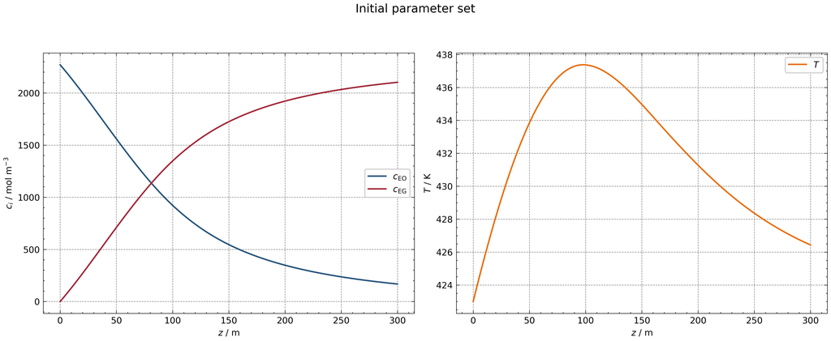

```python
# Initial conditions

y0 = np.array([
    c_EO_in,                    # initial EO concentration, mol m^-3
    c_EG_in,                    # initial EG concentration, mol m^-3
    T_in                        # initial temperature, K
])

# Integration domain along reactor length

z_span = (0.0, L)               # integration interval, m
z_eval = np.linspace(0.0, L, 500)  # axial positions for solution output, m

# Solve initial value problem

solution = solve_ivp(
    fun=pftr,
    t_span=z_span,
    y0=y0,
    t_eval=z_eval,
    method="RK45"
)

# Extract solution data

z = solution.t                  # axial reactor coordinate, m

c_EO = solution.y[0]            # EO concentration, mol m^-3
c_EG = solution.y[1]            # EG concentration, mol m^-3
T = solution.y[2]               # temperature, K

# Plot concentration and temperature profiles

fig, axes = plt.subplots(1, 2, figsize=(12, 5), dpi=500)

fig.suptitle(
    "Initial parameter set",
    fontsize=12
)

# Concentration profiles

axes[0].plot(z, c_EO, label=r"$c_{\mathrm{EO}}$", color=ICIWcolors.CERULEAN)
axes[0].plot(z, c_EG, label=r"$c_{\mathrm{EG}}$", color=ICIWcolors.CRIMSON)

axes[0].set_xlabel(r"$z$ / m")
axes[0].set_ylabel(r"$c_i$ / mol m$^{-3}$")
axes[0].legend()

# Temperature profile

axes[1].plot(z, T, label=r"$T$", color=ICIWcolors.FLAME)

axes[1].set_xlabel(r"$z$ / m")
axes[1].set_ylabel(r"$T$ / K")
axes[1].legend()

plt.tight_layout(rect=[0, 0, 1, 0.93])
plt.show()
```

**Figure 2:** Concentration and temperature profiles of the reaction system with given initial parameters.

The $\mathrm{EO}$ concentration decreases along the reactor length, while the $\mathrm{EG}$ concentration increases due to the stoichiometric formation of $\mathrm{EG}$ from $\mathrm{EO}$. In the first part of the reactor, the $\mathrm{EO}$ concentration is still high and the exothermic reaction causes a temperature rise. Therefore, the reaction proceeds rapidly and the $\mathrm{EO}$ profile is almost linear up to approximately 75 m.

The temperature reaches a maximum at around 100 m. Before this point, heat generation by reaction dominates over heat removal through the reactor wall. Afterwards, heat removal becomes dominant and the temperature decreases again.

$$ \text{heat generation} > \text{heat removal} \quad \Rightarrow \quad T \text{ increases} $$

$$ \text{heat generation} < \text{heat removal} \quad \Rightarrow \quad T \text{ decreases} $$

After the temperature maximum, both the decreasing $\mathrm{EO}$ concentration and the decreasing temperature reduce the reaction rate. Consequently, $\mathrm{EO}$ is consumed more slowly in the second part of the reactor, and the concentration profile becomes flatter. The $\mathrm{EG}$ concentration follows the opposite trend because $\mathrm{EG}$ is formed stoichiometrically from $\mathrm{EO}$.

### 3.4 Conversion

The reactor performance is evaluated from the concentration profiles of $\mathrm{EO}$ and $\mathrm{EG}$. The conversion describes the fraction of initially supplied $\mathrm{EO}$ that has reacted:

\begin{equation} X_{\mathrm{EO}} = \frac{c_{\mathrm{EO},0} - c_{\mathrm{EO}}}{c_{\mathrm{EO},0}} \tag{38} \end{equation}

Since the reaction system only consists of the reaction $A \rightarrow B$, this is equal to the yield $Y$. The conversion can be calculated at the outlet which is an important reactor performance indicator. Additionally, the conversion can also be calculated for incremental steps of the reactor length. Therefore, a conversion-profile can be visualized.

```python
def calculate_conversion(c_EO, c_EO_0=c_EO_in):
    """
    Calculate EO conversion along the PFTR.

    Parameters
    ----------
    c_EO : float or array-like
        EO concentration, mol m^-3
    c_EO_0 : float
        Initial EO concentration, mol m^-3

    Returns
    -------
    X_EO : float or array-like
        EO conversion, -
    """
    c_EO = np.asarray(c_EO)

    X_EO = (c_EO_0 - c_EO) / c_EO_0         # EO conversion, -

    return X_EO
```

```
Outlet EO conversion = 0.9260
```

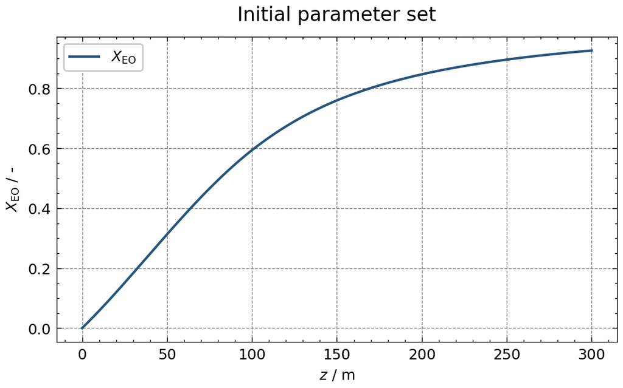

```python
X_EO = calculate_conversion(c_EO)
X_EO_out = calculate_conversion(c_EO[-1])

print(f"Outlet EO conversion = {X_EO_out:.4f}")

# Plot conversion profile

plt.figure(figsize=(5.5, 3.5), dpi=200)

plt.plot(
    z,
    X_EO,
    label=r"$X_{\mathrm{EO}}$",
    color=ICIWcolors.CERULEAN
)

plt.title("Initial parameter set", fontsize=12)
plt.xlabel(r"$z$ / m")
plt.ylabel(r"$X_{\mathrm{EO}}$ / -")
plt.legend()

plt.tight_layout()
plt.show()
```

**Figure 3:** $\mathrm{EO}$ conversion along the reactor length for the initial parameter set.

The $\mathrm{EO}$ conversion increases continuously from the reactor inlet to the outlet and reaches a final value of approximately 0.93 at 300 m. The profile is qualitatively equal to the $\mathrm{EG}$ concentration profile because $\mathrm{EG}$ is formed directly from $\mathrm{EO}$ in a 1:1 stoichiometric ratio.

The conversion increases strongly in the first part of the reactor, where the reaction rate is high due to the high $\mathrm{EO}$ concentration and increasing temperature. Further downstream, the curve becomes flatter because $\mathrm{EO}$ is already depleted and the temperature decreases after the maximum. Therefore, the conversion is used as the main performance criterion in the later parameter studies.

### 3.5 Verification of the Mass and Energy Balances

The implemented mass and energy balances are verified using simple hand calculations. This verification is not intended to replace the numerical solution, but to check whether the implemented balances are consistent with the reaction stoichiometry and the adiabatic energy balance.

For the considered hydrolysis reaction, $\mathrm{EO}$ reacts with water to form $\mathrm{EG}$ in a stoichiometric ratio of 1:1.

\begin{equation} \mathrm{EO} + \mathrm{H_2O} \rightarrow \mathrm{EG} \tag{39} \end{equation}

Since one mole of $\mathrm{EG}$ is formed for each mole of $\mathrm{EO}$ consumed, the sum of the $\mathrm{EO}$ and $\mathrm{EG}$ concentrations must remain constant.

\begin{equation} c_{\mathrm{EO}} + c_{\mathrm{EG}} = c_{\mathrm{EO,in}} + c_{\mathrm{EG,in}} \tag{40} \end{equation}

With $c_{\mathrm{EG,in}}=0$, this simplifies to:

\begin{equation} c_{\mathrm{EO}} + c_{\mathrm{EG}} = c_{\mathrm{EO,in}} \tag{41} \end{equation}

In addition, the $\mathrm{EO}$ conversion and the $\mathrm{EG}$ yield must be identical because of the 1:1 stoichiometry.

\begin{equation} X_{\mathrm{EO}} = \frac{c_{\mathrm{EO,in}} - c_{\mathrm{EO}}}{c_{\mathrm{EO,in}}} \tag{42} \end{equation}

\begin{equation} Y_{\mathrm{EG}} = \frac{c_{\mathrm{EG}} - c_{\mathrm{EG,in}}}{c_{\mathrm{EO,in}}} \tag{43} \end{equation}

For the simplified reaction system, this gives:

\begin{equation} Y_{\mathrm{EG}} = X_{\mathrm{EO}} \tag{44} \end{equation}

For the adiabatic case, the energy balance can be checked by calculating the temperature increase from the converted amount of $\mathrm{EO}$.

\begin{equation} \rho c_p \left( T - T_{\mathrm{in}} \right) = -\Delta_{\mathrm{R}}H \left( c_{\mathrm{EO,in}} - c_{\mathrm{EO}} \right) \tag{45} \end{equation}

Using the $\mathrm{EO}$ conversion, the expected adiabatic temperature is:

\begin{equation} T_{\mathrm{ad}} = T_{\mathrm{in}} + \frac{ -\Delta_{\mathrm{R}}H \cdot c_{\mathrm{EO,in}} }{ \rho c_p } X_{\mathrm{EO}} \tag{46} \end{equation}

The following verification compares the numerical solution with these hand-calculated relationships. Small deviations are expected due to numerical rounding.

```python
# Selected reactor positions for validation, m
z_check = np.array([0.0, 50.0, 150.0, 300.0])

# Interpolate simulated profiles at selected reactor positions
c_EO_check = np.interp(z_check, z, c_EO)
c_EG_check = np.interp(z_check, z, c_EG)
T_check = np.interp(z_check, z, T)

# Calculate conversion and yield independently
X_EO_check = calculate_conversion(c_EO_check)
Y_EG_check = (c_EG_check - c_EG_in) / c_EO_in

# Check stoichiometric concentration sum
c_sum_check = c_EO_check + c_EG_check

# Calculate reaction rate at selected reactor positions
r_check = kinetics(c_EO_check, T_check)

# Calculate heat generation term from reaction, J m^-3 s^-1
q_reaction_check = -delta_H_R * r_check

# Calculate heat transfer term through the reactor wall, J m^-3 s^-1
q_wall_check = (4 * h_wall / d_R) * (T_check - T_wall)

# Create validation table with plain internal column names
validation_table = pd.DataFrame({
    "z / m": z_check,
    "c_EO / mol m^-3": c_EO_check,
    "c_EG / mol m^-3": c_EG_check,
    "c_EO + c_EG / mol m^-3": c_sum_check,
    "X_EO / -": X_EO_check,
    "Y_EG / -": Y_EG_check,
    "T / K": T_check,
    "r / mol m^-3 s^-1": r_check,
    "heat generation / J m^-3 s^-1": q_reaction_check,
    "heat removal / J m^-3 s^-1": q_wall_check
})

# Round values for report-ready display
validation_table = validation_table.round({
    "z / m": 1,
    "c_EO / mol m^-3": 2,
    "c_EG / mol m^-3": 2,
    "c_EO + c_EG / mol m^-3": 2,
    "X_EO / -": 4,
    "Y_EG / -": 4,
    "T / K": 2,
    "r / mol m^-3 s^-1": 4,
    "heat generation / J m^-3 s^-1": 2,
    "heat removal / J m^-3 s^-1": 2
})

# Rename only for displayed Markdown table
display_table = validation_table.rename(columns={
    "c_EO / mol m^-3": "c_EO / mol m⁻³",
    "c_EG / mol m^-3": "c_EG / mol m⁻³",
    "c_EO + c_EG / mol m^-3": "c_EO + c_EG / mol m⁻³",
    "X_EO / -": "X_EO / -",
    "Y_EG / -": "Y_EG / -",
    "r / mol m^-3 s^-1": "r / mol m⁻³ s⁻¹",
    "heat generation / J m^-3 s^-1": "heat generation / J m⁻³ s⁻¹",
    "heat removal / J m^-3 s^-1": "heat removal / J m⁻³ s⁻¹"
})

# Display as Markdown table
display(Markdown("**Table 3:** Manual validation values for the implemented mass and energy balances."))
display(Markdown(display_table.to_markdown(index=False)))
```

**Table 3:** Manual validation values for the implemented mass and energy balances.

| z / m | c_EO / mol m⁻³ | c_EG / mol m⁻³ | c_EO + c_EG / mol m⁻³ | X_EO / - | Y_EG / - | T / K | r / mol m⁻³ s⁻¹ | heat generation / J m⁻³ s⁻¹ | heat removal / J m⁻³ s⁻¹ |
| --- | --- | --- | --- | --- | --- | --- | --- | --- | --- |
| 0 | 2270 | 0 | 2270 | 0 | 0 | 423 | 12.6452 | 1.16589e+06 | 0 |
| 50 | 1559.69 | 710.31 | 2270 | 0.3129 | 0.3129 | 433.84 | 14.5451 | 1.34106e+06 | 722909 |
| 150 | 545.86 | 1724.14 | 2270 | 0.7595 | 0.7595 | 434.97 | 5.3621 | 494390 | 797915 |
| 300 | 167.97 | 2102.03 | 2270 | 0.926 | 0.926 | 426.44 | 1.1048 | 101862 | 229074 |

The validation table confirms that the implemented mass balances are consistent with the reaction stoichiometry. At all evaluated reactor positions, the sum of the $\mathrm{EO}$ and $\mathrm{EG}$ concentrations remains constant at $2270~\mathrm{mol \; m^{-3}}$. This shows that the consumption of $\mathrm{EO}$ and the formation of $\mathrm{EG}$ are balanced correctly.

The calculated $\mathrm{EO}$ conversion and $\mathrm{EG}$ yield are identical at each position. This agrees with the 1:1 stoichiometry of the hydrolysis reaction and confirms that the yield and conversion definitions are implemented consistently.

The energy balance is also plausible. At the reactor inlet, heat removal is zero because the fluid temperature is equal to the wall temperature. Along the reactor, the reaction generates heat and the wall removes part of this heat once the reactor temperature exceeds the wall temperature. Between $50~\mathrm{m}$ and $150~\mathrm{m}$, heat removal becomes larger than heat generation, which explains why the temperature reaches a maximum and then decreases further downstream. At the reactor outlet, both the reaction rate and heat generation are low because most of the $\mathrm{EO}$ has already been converted. Overall, the validation confirms that the implemented mass and energy balances behave consistently.

## 4. Variation of Process Parameters

### 4.1 Influence of Inlet Temperature

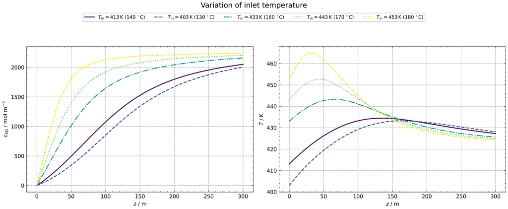

```python
# Inlet temperature variation

T_in_offsets = np.array([-10, -20, 10, 20, 30])  # temperature offsets, K
T_in_values = T_in + T_in_offsets                # inlet temperatures, K

temperature_variation_results = {}

for T_in_current in T_in_values:

    y0 = np.array([
        c_EO_in,                    # initial EO concentration, mol m^-3
        c_EG_in,                    # initial EG concentration, mol m^-3
        T_in_current                # initial temperature, K
    ])

    solution = solve_ivp(
        fun=pftr,
        t_span=(0.0, L),
        y0=y0,
        t_eval=z_eval,
        method="RK45"
    )

    temperature_variation_results[T_in_current] = solution

# Plot product concentration and temperature profiles for varied inlet temperatures

fig, axes = plt.subplots(1, 2, figsize=(12, 5), dpi=500)

fig.suptitle(
    "Variation of inlet temperature",
    fontsize=12
)

colors = plt.cm.viridis(np.linspace(0, 1, len(T_in_values)))
linestyles = ["-", "--", "-.", ":", (0, (3, 1, 1, 1))]

for color, linestyle, T_in_current in zip(
    colors,
    linestyles,
    T_in_values
):

    solution = temperature_variation_results[T_in_current]

    z = solution.t                  # axial reactor coordinate, m
    c_EG = solution.y[1]            # EG concentration, mol m^-3
    T = solution.y[2]               # temperature, K

    T_in_current_C = T_in_current - 273.15  # inlet temperature, °C

    label = (
        rf"$T_\mathrm{{in}} = {T_in_current:.0f}\,\mathrm{{K}}$ "
        rf"$({T_in_current_C:.0f}\,^\circ\mathrm{{C}})$"
    )

    axes[0].plot(z, c_EG, color=color, linestyle=linestyle)
    axes[1].plot(z, T, color=color, linestyle=linestyle)

    axes[0].plot([], [], label=label, color=color, linestyle=linestyle)

axes[0].set_xlabel(r"$z$ / m")
axes[0].set_ylabel(r"$c_{\mathrm{EG}}$ / mol m$^{-3}$")

axes[1].set_xlabel(r"$z$ / m")
axes[1].set_ylabel(r"$T$ / K")

handles, labels = axes[0].get_legend_handles_labels()

fig.legend(
    handles,
    labels,
    loc="upper center",
    ncol=len(T_in_values),
    fontsize=8,
    bbox_to_anchor=(0.5, 0.94)
)

plt.tight_layout(rect=[0, 0, 1, 0.86])
plt.show()
```

**Figure 4:** Concentration and temperature profiles along the PFTR for varied inlet temperatures of $403\,\mathrm{K}$, $413\,\mathrm{K}$, $433\,\mathrm{K}$, $443\,\mathrm{K}$ and $453\,\mathrm{K}$.

The variation of the inlet temperature shows a clear influence on the reaction intensity inside the PFTR. At lower inlet temperatures, the reaction rate is reduced due to the lower Arrhenius rate constant. As a result, $\mathrm{EG}$ formation is slower, the concentration profile is shallower and the outlet conversion remains lower. The temperature profile also increases more moderately because less reaction heat is released per reactor length.

At higher inlet temperatures, the opposite behaviour is observed. The higher rate constant increases the $\mathrm{EO}$ hydrolysis rate, leading to faster $\mathrm{EG}$ formation and higher conversion already in the first part of the reactor. The stronger reaction intensity also causes a larger heat release, resulting in more pronounced temperature maxima. This confirms the strong coupling between mass and energy balance for the exothermic $\mathrm{EO}$ hydrolysis.

```python
# Create Markdown table for varied inlet temperatures

markdown_table = """
**Table 4:** Outlet conversion of varied inlet temperature streams

| $T_{\\mathrm{in}}\\,/\\,\\mathrm{K}$ | $\\Delta T_{\\mathrm{in}}\\,/\\,\\mathrm{K}$ | $X_{\\mathrm{EO},\\mathrm{out}}\\,/\\,-$ |
| ---: | ---: | ---: |
"""

for T_in_current, T_offset in sorted(zip(T_in_values, T_in_offsets)):

    solution = temperature_variation_results[T_in_current]

    c_EO_out = solution.y[0, -1]                  # outlet EO concentration, mol m^-3
    X_EO_out = calculate_conversion(c_EO_out)     # outlet EO conversion, -

    markdown_table += (
        f"| {T_in_current:.0f} | "
        f"{T_offset:+.0f} | "
        f"{X_EO_out:.4f} |\n"
    )

display(Markdown(markdown_table))
```

**Table 4:** Outlet conversion of varied inlet temperature streams

| $T_{\mathrm{in}}\,/\,\mathrm{K}$ | $\Delta T_{\mathrm{in}}\,/\,\mathrm{K}$ | $X_{\mathrm{EO},\mathrm{out}}\,/\,-$ |
| --- | --- | --- |
| 403 | -20 | 0.8812 |
| 413 | -10 | 0.9029 |
| 433 | +10 | 0.9500 |
| 443 | +20 | 0.9701 |
| 453 | +30 | 0.9869 |

### 4.2 Influence of Wall Temperature - Cooling performance

The cooling or wall temperature is an important process parameter for the thermal control of the PFTR. In industrial operation, the cooling temperature may vary due to changes in the utility system or due to technical disturbances in the cooling equipment. Since the hydrolysis of $\mathrm{EO}$ is strongly exothermic, such variations can directly affect heat removal and therefore the thermal stability of the reactor.

For this reason, the wall temperature $T_\mathrm{K}$ is varied while the reactor geometry and the remaining process parameters are kept constant. The aim is to investigate how strongly the reactor temperature profile responds to reduced cooling performance. A higher wall temperature decreases the temperature difference between reactor and cooling medium, which reduces heat removal from the reactor.

The expected effect is an increase in the maximum reactor temperature $T_\mathrm{max}$ and potentially a shift of the temperature maximum along the reactor length. At the same time, the higher reactor temperature can increase the reaction rate and therefore influence the conversion of $\mathrm{EO}$. This parameter study is therefore used to identify a safe upper limit for the cooling temperature, at which the reactor can still be thermally controlled without excessive temperature maxima.

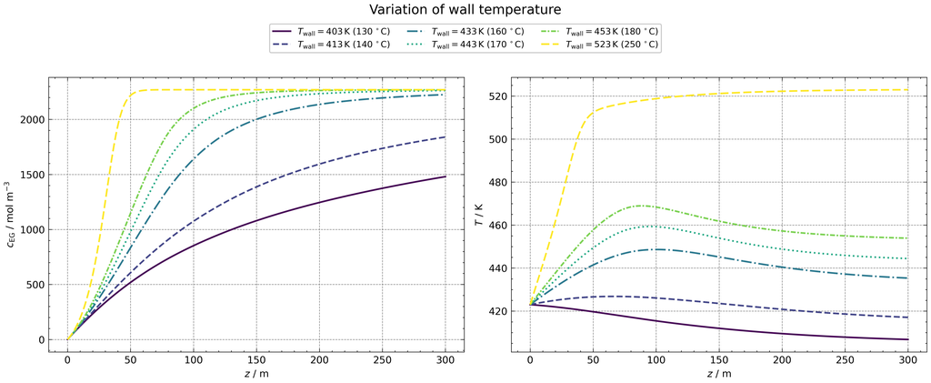

```python
# Wall temperature variation

T_wall_values = np.array([
    T_wall - 20,     # lower wall temperature, K
    T_wall - 10,     # lower wall temperature, K
    T_wall + 10,     # higher wall temperature, K
    T_wall + 20,     # higher wall temperature, K
    T_wall + 30,     # higher wall temperature, K
    523.15           # wall temperature of 250 °C, K
])

# Store base wall temperature

T_wall_base = T_wall                                # base wall temperature, K

# Solve PFTR for all wall temperatures

wall_temperature_variation_results = {}

for T_wall_current in T_wall_values:

    T_wall = T_wall_current                         # overwrite wall temperature, K

    y0 = np.array([
        c_EO_in,                                    # initial EO concentration, mol m^-3
        c_EG_in,                                    # initial EG concentration, mol m^-3
        T_in                                        # initial temperature, K
    ])

    solution = solve_ivp(
        fun=pftr,
        t_span=(0.0, L),
        y0=y0,
        t_eval=z_eval,
        method="RK45"
    )

    wall_temperature_variation_results[T_wall_current] = solution

# Restore base wall temperature

T_wall = T_wall_base

# Plot product concentration and temperature profiles for wall temperature variation

fig, axes = plt.subplots(1, 2, figsize=(12, 5), dpi=500)

fig.suptitle(
    "Variation of wall temperature",
    fontsize=12
)

colors = plt.cm.viridis(np.linspace(0, 1, len(T_wall_values)))
linestyles = ["-", "--", "-.", ":", (0, (3, 1, 1, 1)), (0, (5, 2))]

for color, linestyle, T_wall_current in zip(colors, linestyles, T_wall_values):

    solution = wall_temperature_variation_results[T_wall_current]

    z = solution.t                                  # axial reactor coordinate, m
    c_EG = solution.y[1]                            # EG concentration, mol m^-3
    T = solution.y[2]                               # temperature, K

    T_wall_C = T_wall_current - 273.15              # wall temperature, °C

    label = (
        rf"$T_\mathrm{{wall}} = {T_wall_current:.0f}\,\mathrm{{K}}$ "
        rf"$({T_wall_C:.0f}\,^\circ\mathrm{{C}})$"
    )

    axes[0].plot(z, c_EG, color=color, linestyle=linestyle)
    axes[1].plot(z, T, color=color, linestyle=linestyle)

    axes[0].plot([], [], label=label, color=color, linestyle=linestyle)

axes[0].set_xlabel(r"$z$ / m")
axes[0].set_ylabel(r"$c_{\mathrm{EG}}$ / mol m$^{-3}$")

axes[1].set_xlabel(r"$z$ / m")
axes[1].set_ylabel(r"$T$ / K")

for ax in axes:
    ax.grid(True)

handles, labels = axes[0].get_legend_handles_labels()

fig.legend(
    handles,
    labels,
    loc="upper center",
    ncol=3,
    fontsize=8,
    bbox_to_anchor=(0.5, 0.94)
)

plt.tight_layout(rect=[0, 0, 1, 0.88])
plt.show()
```

**Figure 5:** Concentration- and Temperature-profiles for varied cooling temperatures.

The variation of the wall temperature shows a similar qualitative influence on the concentration and temperature profiles as the variation of the inlet temperature. Higher wall temperatures reduce the cooling driving force and therefore lead to higher reactor temperatures. As a result, the reaction rate increases and $\mathrm{EG}$ formation becomes faster along the reactor length. Lower wall temperatures show the opposite behaviour: stronger heat removal lowers the reactor temperature, reduces the reaction intensity and leads to shallower concentration profiles.

The outlet conversions show that the wall temperature has a stronger influence on the final conversion than the inlet temperature variation. At low wall temperatures, the conversion is significantly lower, reaching only $0.6521$ at $403\,\mathrm{K}$. This is because the colder wall continuously removes heat along the entire reactor length and suppresses the temperature rise caused by the exothermic reaction. In contrast, when only the inlet temperature is lowered, the colder inlet stream can still be heated by the warmer reactor wall and by the released reaction heat, so the conversion remains higher.

At higher wall temperatures, the opposite effect is observed. A warmer wall reduces the cooling driving force over the whole reactor length and maintains a higher reactor temperature. This increases the reaction rate and leads to very high outlet conversions, with almost complete conversion at $453\,\mathrm{K}$. Therefore, the wall temperature affects not only the inlet region but the thermal conditions of the entire reactor, making it more influential for the final conversion than the inlet temperature alone.

For a wall temperature of $523\,\mathrm{K}$, the outlet conversion becomes very high. This temperature is within the typical industrial operating range reported for $\mathrm{EO}$ hydration [3]. The high wall temperature leads to continuous heat input into the reactor as long as the reactor temperature is below the wall temperature. Therefore, the reaction is strongly accelerated and $\mathrm{EO}$ is converted very effectively.

```python
# Create sorted Markdown table for outlet conversion comparison

markdown_table = """
**Table 5:** Outlet conversion comparison of varied inlet and wall temperature streams

| Temperature $T$ / K (°C) | Temperature offset $\\Delta T$ / K | $X_{\\mathrm{EO,out}}$ for varied $T_{\\mathrm{in}}$ / - | $X_{\\mathrm{EO,out}}$ for varied $T_{\\mathrm{wall}}$ / - |
| ---: | ---: | ---: | ---: |
"""

for T_current in sorted(T_wall_values):

    T_offset = T_current - T_wall_base               # temperature offset relative to base wall temperature, K
    T_current_C = T_current - 273.15                 # temperature, °C

    # Inlet-temperature variation only exists for previously simulated inlet temperatures
    if T_current in temperature_variation_results:
        solution_in = temperature_variation_results[T_current]
        c_EO_out_in = solution_in.y[0, -1]           # outlet EO concentration, mol m^-3
        X_EO_out_in = calculate_conversion(c_EO_out_in)
        X_EO_out_in_label = f"{X_EO_out_in:.4f}"
    else:
        X_EO_out_in_label = "-"

    solution_wall = wall_temperature_variation_results[T_current]
    c_EO_out_wall = solution_wall.y[0, -1]           # outlet EO concentration, mol m^-3
    X_EO_out_wall = calculate_conversion(c_EO_out_wall)

    markdown_table += (
        f"| {T_current:.0f} ({T_current_C:.0f} °C) | "
        f"{T_offset:+.0f} | "
        f"{X_EO_out_in_label} | "
        f"{X_EO_out_wall:.4f} |\n"
    )

display(Markdown(markdown_table))
```

**Table 5:** Outlet conversion comparison of varied inlet and wall temperature streams

| Temperature $T$ / K (°C) | Temperature offset $\Delta T$ / K | $X_{\mathrm{EO,out}}$ for varied $T_{\mathrm{in}}$ / - | $X_{\mathrm{EO,out}}$ for varied $T_{\mathrm{wall}}$ / - |
| --- | --- | --- | --- |
| 403 (130 °C) | -20 | 0.8812 | 0.6521 |
| 413 (140 °C) | -10 | 0.9029 | 0.8107 |
| 433 (160 °C) | +10 | 0.9500 | 0.9805 |
| 443 (170 °C) | +20 | 0.9701 | 0.9969 |
| 453 (180 °C) | +30 | 0.9869 | 0.9997 |
| 523 (250 °C) | +100 | - | 1.0000 |

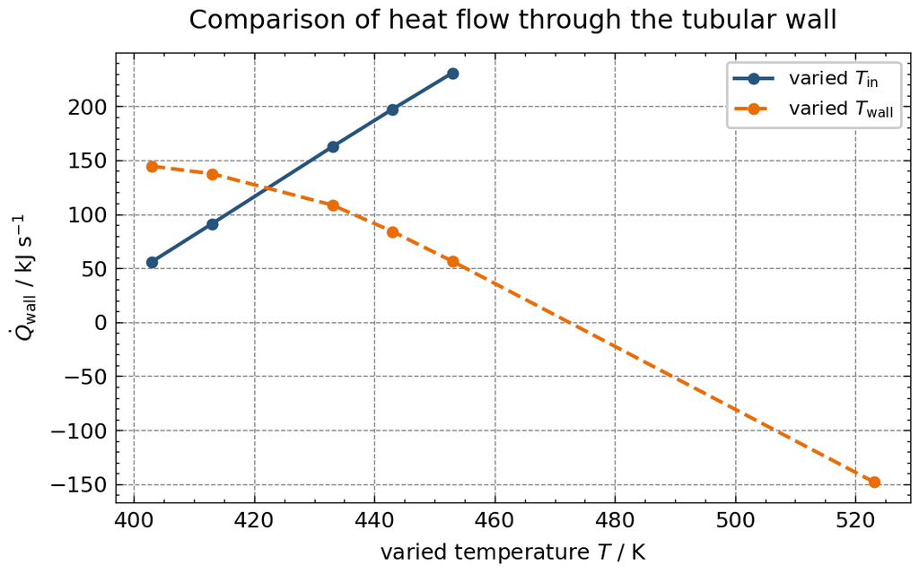

```python
# Calculate and plot total heat flow through the tubular wall

Q_wall_inlet_variation = []
Q_wall_wall_variation = []

T_in_sorted = np.array(sorted(T_in_values))          # varied inlet temperatures, K
T_wall_sorted = np.array(sorted(T_wall_values))      # varied wall temperatures, K

# Case 1: varied inlet temperature, wall temperature remains constant

for T_in_current in T_in_sorted:

    solution_in = temperature_variation_results[T_in_current]

    z_in = solution_in.t                            # axial reactor coordinate, m
    T_profile_in = solution_in.y[2]                 # temperature profile, K

    Q_wall_in = np.trapezoid(
        h_wall * (T_profile_in - T_wall_base) * np.pi * d_R,
        z_in
    )                                               # heat flow through wall, J s^-1

    Q_wall_inlet_variation.append(Q_wall_in)

# Case 2: varied wall temperature, inlet temperature remains constant

for T_wall_current in T_wall_sorted:

    solution_wall = wall_temperature_variation_results[T_wall_current]

    z_wall = solution_wall.t                        # axial reactor coordinate, m
    T_profile_wall = solution_wall.y[2]             # temperature profile, K

    Q_wall_wall = np.trapezoid(
        h_wall * (T_profile_wall - T_wall_current) * np.pi * d_R,
        z_wall
    )                                               # heat flow through wall, J s^-1

    Q_wall_wall_variation.append(Q_wall_wall)

Q_wall_inlet_variation = np.array(Q_wall_inlet_variation)
Q_wall_wall_variation = np.array(Q_wall_wall_variation)

# Plot heat flow comparison

plt.figure(figsize=(5.5, 3.5), dpi=200)

plt.title(
    "Comparison of heat flow through the tubular wall",
    fontsize=11
)

plt.plot(
    T_in_sorted,
    Q_wall_inlet_variation / 1000,
    marker="o",
    linestyle="-",
    label=r"varied $T_{\mathrm{in}}$",
    color=ICIWcolors.CERULEAN
)

plt.plot(
    T_wall_sorted,
    Q_wall_wall_variation / 1000,
    marker="o",
    linestyle="--",
    label=r"varied $T_{\mathrm{wall}}$",
    color=ICIWcolors.FLAME
)

plt.xlabel(r"varied temperature $T$ / K")
plt.ylabel(r"$\dot{Q}_{\mathrm{wall}}$ / kJ s$^{-1}$")
plt.legend(fontsize=8)
plt.grid(True)

plt.tight_layout()
plt.show()
```

**Figure 6:** Heat flow through the reactor wall for varied inlet and wall temperatures. The inlet temperature variation shows that lower inlet temperatures lead to lower heat removal, while higher inlet temperatures increase the cooling duty. For the wall temperature variation, the opposite trend is observed because higher wall temperatures reduce the temperature difference between reactor fluid and wall.

For the inlet temperature variation, the heat flow through the reactor wall increases with increasing inlet temperature. Lower inlet temperatures lead to lower reactor temperatures and therefore to a smaller temperature difference between reactor fluid and wall. As a result, less heat is removed. At higher inlet temperatures, the reactor temperature level is increased and the exothermic reaction is intensified, which increases the required cooling duty.

For the wall temperature variation, the trend is opposite. Higher wall temperatures reduce the cooling driving force between reactor fluid and wall, so less heat is removed even though the reaction becomes more intense. This shows that the cooling duty is controlled not only by the heat released by the reaction, but also by the available temperature difference for heat transfer.

### 4.3 Heat-Removal Boundary Cases: Adiabatic, Polytropic and Isothermal PFTR Behaviour

After the process parameter study, the influence of heat removal is investigated more generally by comparing three limiting cases of the PFTR: adiabatic, polytropic and isothermal operation. The dimensionless mass and energy balances introduced in Chapter 2.4 are used for this study. This allows the heat-transfer behaviour to be described by the Stanton number instead of varying the dimensional heat-transfer coefficient directly.

The Stanton number compares heat removal through the reactor wall with convective heat transport through the reactor:

\begin{equation} St = \frac{4 h_{\mathrm{wall}} L_{\mathrm{R}}}{u d_{\mathrm{R}} \rho c_p} \tag{47} \end{equation}

Therefore, the Stanton number is suitable to represent different heat-removal intensities. A low Stanton number corresponds to weak heat removal, while a high Stanton number corresponds to strong heat removal. In this work, the Stanton number is used to define the thermal boundary cases of the reactor.

For adiabatic operation, no heat is removed through the reactor wall. This corresponds to:

\begin{equation} St = 0 \tag{48} \end{equation}

In this case, the temperature rise is only caused by the heat released by the exothermic hydrolysis of $\mathrm{EO}$. Therefore, the adiabatic case represents the upper thermal boundary of the reactor behaviour. It is especially relevant for evaluating the maximum possible temperature increase and the thermal risk in the absence of cooling.

For polytropic operation, finite heat removal is considered:

\begin{equation} 0 < St < \infty \tag{49} \end{equation}

This case corresponds to the real cooled PFTR model used in the previous parameter studies. Heat is generated by the reaction and removed through the reactor wall at the same time. Therefore, the temperature profile results from the balance between reaction heat generation and heat removal. The polytropic case is expected to lie between the adiabatic and isothermal limits.

For isothermal operation, ideal heat removal is assumed. The reactor temperature is kept constant along the complete reactor length:

\begin{equation} \vartheta(\zeta) = 1 \tag{50} \end{equation}

This means that the heat released by the reaction is removed immediately. In this limiting case, the energy balance is replaced by the fixed-temperature condition, and only the dimensionless mass balances are solved. The isothermal case represents the lower thermal boundary because no temperature rise occurs.

The comparison of these three cases is useful because it shows how strongly the $\mathrm{EO}$ conversion and reactor temperature depend on heat removal. The adiabatic case gives the maximum temperature rise, the isothermal case gives the ideal heat-removal limit, and the polytropic case represents practical operation with finite cooling.

In terms of reactor safety, this comparison is important because it defines the possible thermal operating range of the PFTR. If the polytropic temperature profile is close to the adiabatic case, heat removal is weak and the reactor may become thermally critical. If the polytropic case approaches the isothermal case, heat removal is strong enough to suppress large temperature increases.

The limiting heat-removal cases are implemented in Python using the dimensionless mass and energy balances. For the isothermal case, the Stanton number is set to a very high value of $St = 10^{10}$. This represents an almost infinitely strong heat removal from the reactor and therefore approximates isothermal behaviour.

For the polytropic base case, the Stanton number is calculated from the base reactor and process parameters:

\begin{equation} St = \frac{4 h_{\mathrm{wall}} L_{\mathrm{R}}}{u d_{\mathrm{R}} \rho c_p} = 4.77 \tag{51} \end{equation}

This value is used as the reference case for finite heat removal. In addition, the Stanton number is varied to investigate weaker and stronger heat-transfer behaviour:

\begin{equation} St = \begin{bmatrix} 2 & 3 & 4.77 & 8 & 10 \end{bmatrix} \tag{52} \end{equation}

Lower Stanton numbers represent weaker heat removal, while higher Stanton numbers represent stronger heat removal. This allows the transition between nearly adiabatic, polytropic and nearly isothermal PFTR behaviour to be compared.

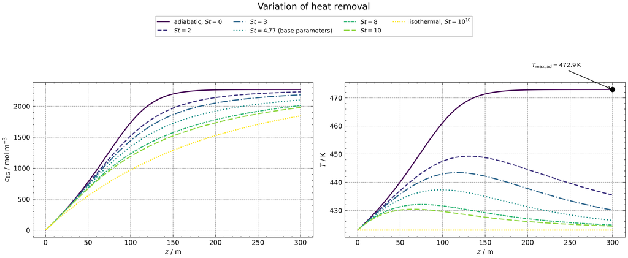

```python
# Heat-removal boundary cases and intermediate Stanton numbers

St_base = 4 * h_wall * L / (u * d_R * rho * cp)   # base Stanton number, -

St_values = {
    "adiabatic": 0.0,
    "St = 2": 2.0,
    "St = 3": 3.0,
    "St = 4.77": St_base,
    "St = 8": 8.0,
    "St = 10": 10.0,
    "isothermal": 1e10
}

# Solve PFTR for all Stanton numbers

thermal_case_results = {}
thermal_case_h_values = {}

u_base = u
h_wall_base = h_wall

for case_name, St_current in St_values.items():

    h_wall = St_current * u * d_R * rho * cp / (4 * L)  # heat-transfer coefficient, J s^-1 m^-2 K^-1

    y0 = np.array([
        c_EO_in,                # initial EO concentration, mol m^-3
        c_EG_in,                # initial EG concentration, mol m^-3
        T_in                    # initial temperature, K
    ])

    solution = solve_ivp(
        fun=pftr,
        t_span=(0.0, L),
        y0=y0,
        t_eval=z_eval,
        method="Radau"
    )

    thermal_case_results[case_name] = solution
    thermal_case_h_values[case_name] = h_wall

# Restore base values

h_wall = h_wall_base
u = u_base

# Plot product concentration and temperature profiles for thermal boundary cases

fig, axes = plt.subplots(1, 2, figsize=(12, 5), dpi=500)

fig.suptitle(
    "Variation of heat removal",
    fontsize=12
)

colors = plt.cm.viridis(np.linspace(0, 1, len(St_values)))
linestyles = ["-", "--", "-.", ":", (0, (3, 1, 1, 1)), (0, (5, 2)), (0, (1, 1))]

for color, linestyle, (case_name, St_current) in zip(colors, linestyles, St_values.items()):

    solution = thermal_case_results[case_name]

    z = solution.t              # axial reactor coordinate, m
    c_EG = solution.y[1]        # EG concentration, mol m^-3
    T = solution.y[2]           # temperature, K

    if case_name == "St = 4.77":
        label = rf"$St = {St_current:.2f}$ (base parameters)"
    elif case_name == "isothermal":
        label = r"isothermal, $St = 10^{10}$"
    elif case_name == "adiabatic":
        label = r"adiabatic, $St = 0$"
    else:
        label = rf"$St = {St_current:.0f}$"

    axes[0].plot(z, c_EG, color=color, linestyle=linestyle)
    axes[1].plot(z, T, color=color, linestyle=linestyle)

    axes[0].plot([], [], label=label, color=color, linestyle=linestyle)

# Mark first point where maximum temperature of adiabatic case is reached

adiabatic_solution = thermal_case_results["adiabatic"]

z_adiabatic = adiabatic_solution.t          # axial reactor coordinate, m
T_adiabatic = adiabatic_solution.y[2]       # adiabatic temperature profile, K

idx_T_max = np.argmax(T_adiabatic)          # first index of maximum temperature

z_T_max = z_adiabatic[idx_T_max]            # position of maximum temperature, m
T_max_adiabatic = T_adiabatic[idx_T_max]    # maximum adiabatic temperature, K

axes[1].plot(
    z_T_max,
    T_max_adiabatic,
    marker="o",
    markersize=6,
    color="black",
    linestyle="none"
)

axes[1].annotate(
    rf"$T_{{\mathrm{{max,ad}}}} = {T_max_adiabatic:.1f}\,\mathrm{{K}}$",
    xy=(z_T_max, T_max_adiabatic),
    xytext=(z_T_max - 95, T_max_adiabatic + 8),
    arrowprops=dict(arrowstyle="->", linewidth=0.8),
    fontsize=8
)

axes[0].set_xlabel(r"$z$ / m")
axes[0].set_ylabel(r"$c_{\mathrm{EG}}$ / mol m$^{-3}$")

axes[1].set_xlabel(r"$z$ / m")
axes[1].set_ylabel(r"$T$ / K")

for ax in axes:
    ax.grid(True)

handles, labels = axes[0].get_legend_handles_labels()

fig.legend(
    handles,
    labels,
    loc="upper center",
    ncol=4,
    fontsize=8,
    bbox_to_anchor=(0.5, 0.94)
)

plt.tight_layout(rect=[0, 0, 1, 0.86])
plt.show()
```

**Figure 7:** $\mathrm{EG}$ concentration and temperature profiles along the PFTR for different heat-removal cases. The figure compares adiabatic operation, several polytropic cases with different Stanton numbers and the isothermal limiting case.

For the polytropic cases, the temperature first increases because reaction heat generation dominates. After the temperature maximum is reached, heat removal through the reactor wall becomes dominant and the temperature decreases again. A higher Stanton number leads to stronger heat removal, lower maximum temperatures and an earlier reduction of the temperature profile. The maximum temperature decreases from $T_\mathrm{max}=449.24~\mathrm{K}$ at $St=2$ to $T_\mathrm{max}=437.29~\mathrm{K}$ for the base polytropic case and further to $T_\mathrm{max}=430.41~\mathrm{K}$ at $St=10$.

The isothermal case represents the lower thermal boundary. Since ideal heat removal is assumed, the reactor temperature remains constant along the complete reactor length. Therefore, the reaction proceeds only due to the concentration decrease and not due to additional thermal acceleration. In Table 6, this is shown by $T_\mathrm{out}=T_\mathrm{max}=423.00~\mathrm{K}$.

Overall, the figure and Table 6 show that the Stanton number controls the transition between the two limiting cases. Low Stanton numbers approach adiabatic behaviour with high temperature rise and fast upstream conversion. High Stanton numbers approach isothermal behaviour with lower temperature rise and more evenly distributed $\mathrm{EG}$ formation along the reactor length. Therefore, the base polytropic case with $St=4.77$ lies between both limiting cases and represents finite heat removal under realistic reactor operation.

```python
# Calculate outlet conversion for all heat-removal cases

thermal_case_conversion = []

for case_name, St_current in St_values.items():
    solution = thermal_case_results[case_name]

    c_EO_out = solution.y[0, -1]                         # outlet EO concentration, mol m^-3
    c_EG_out = solution.y[1, -1]                         # outlet EG concentration, mol m^-3
    T_out = solution.y[2, -1]                            # outlet temperature, K
    T_max = np.max(solution.y[2])                        # maximum reactor temperature, K
    X_EO_out = (c_EO_in - c_EO_out) / c_EO_in            # outlet EO conversion, -

    thermal_case_conversion.append([
        case_name,
        St_current,
        thermal_case_h_values[case_name],
        c_EG_out,
        X_EO_out,
        T_out,
        T_max
    ])

# Create Markdown table

table_md = """
<p align="left"><strong>Table 6:</strong> Outlet conversion and temperature results for different heat-removal cases.</p>

| Case | $St$ / - | $h_\\mathrm{wall}$ / J s⁻¹ m⁻² K⁻¹ | $c_{\\mathrm{EG},out}$ / mol m⁻³ | $X_{\\mathrm{EO},out}$ / - | $T_\\mathrm{out}$ / K | $T_\\mathrm{max}$ / K |
| --- | ---: | ---: | ---: | ---: | ---: | ---: |
"""

for case_name, St_current, h_current, c_EG_out, X_EO_out, T_out, T_max in thermal_case_conversion:
    if case_name == "adiabatic":
        case_label = "adiabatic"
        St_label = "0"
        h_label = "0"
    elif case_name == "isothermal":
        case_label = "isothermal"
        St_label = "$\\infty$"
        h_label = "$\\infty$"
    elif case_name == "polytropic":
        case_label = "polytropic"
        St_label = f"{St_current:.2f}"
        h_label = f"{h_current:.0f}"
    else:
        case_label = case_name
        St_label = f"{St_current:.0f}"
        h_label = f"{h_current:.0f}"

    table_md += (
        f"| {case_label} | {St_label} | {h_label} | "
        f"{c_EG_out:.1f} | {X_EO_out:.4f} | {T_out:.2f} | {T_max:.2f} |\n"
    )

display(Markdown(table_md))
```

**Table 6:** Outlet conversion and temperature results for different heat-removal cases.

| Case | $St$ / - | $h_\mathrm{wall}$ / J s⁻¹ m⁻² K⁻¹ | $c_{\mathrm{EG},out}$ / mol m⁻³ | $X_{\mathrm{EO},out}$ / - | $T_\mathrm{out}$ / K | $T_\mathrm{max}$ / K |
| --- | --- | --- | --- | --- | --- | --- |
| adiabatic | 0 | 0 | 2270.0 | 1.0000 | 472.95 | 472.95 |
| St = 2 | 2 | 210 | 2231.8 | 0.9832 | 435.43 | 449.24 |
| St = 3 | 3 | 314 | 2183.1 | 0.9617 | 430.09 | 443.40 |
| St = 4.77 | 5 | 500 | 2101.5 | 0.9258 | 426.45 | 437.29 |
| St = 8 | 8 | 838 | 2011.2 | 0.8860 | 424.80 | 432.09 |
| St = 10 | 10 | 1048 | 1979.7 | 0.8721 | 424.44 | 430.41 |
| isothermal | $\infty$ | $\infty$ | 1843.2 | 0.8120 | 423.00 | 423.00 |

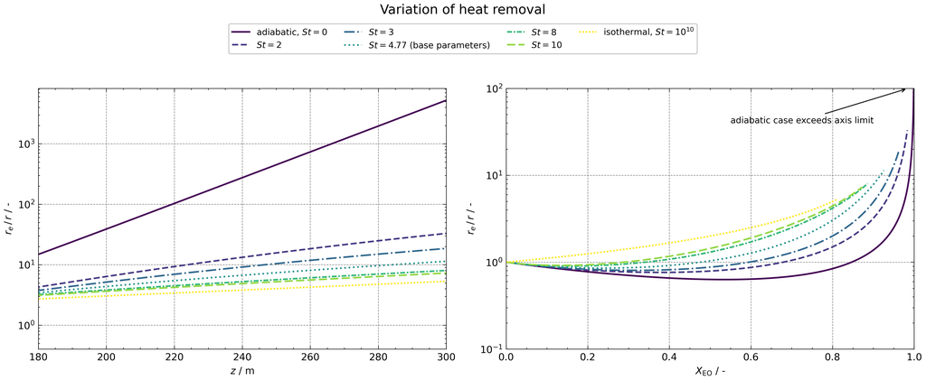

```python
# Plot reaction resistance r_e / r over reactor length and conversion
# Right plot uses clipped logarithmic scale for better readability

r_e = kinetics(c_EO_in, T_in)       # reaction rate at inlet conditions, mol m^-3 s^-1

fig, axes = plt.subplots(1, 2, figsize=(12, 5), dpi=500)

fig.suptitle(
    "Variation of heat removal",
    fontsize=12
)

colors = plt.cm.viridis(np.linspace(0, 1, len(St_values)))
linestyles = ["-", "--", "-.", ":", (0, (3, 1, 1, 1)), (0, (5, 2)), (0, (1, 1))]

for color, linestyle, (case_name, St_current) in zip(colors, linestyles, St_values.items()):

    solution = thermal_case_results[case_name]

    z = solution.t                  # axial reactor coordinate, m
    c_EO = solution.y[0]            # EO concentration, mol m^-3
    T = solution.y[2]               # temperature, K

    r = kinetics(c_EO, T)           # local reaction rate, mol m^-3 s^-1

    reaction_resistance = np.divide(
        r_e,
        r,
        out=np.full_like(r, np.nan, dtype=float),
        where=r > 0
    )                               # reaction resistance, -

    X_EO = calculate_conversion(c_EO)  # EO conversion, -

    if case_name == "St = 4.77":
        label = rf"$St = {St_current:.2f}$ (base parameters)"
    elif case_name == "isothermal":
        label = r"isothermal, $St = 10^{10}$"
    elif case_name == "adiabatic":
        label = r"adiabatic, $St = 0$"
    else:
        label = rf"$St = {St_current:.0f}$"

    axes[0].plot(
        z,
        reaction_resistance,
        color=color,
        linestyle=linestyle
    )

    axes[1].plot(
        X_EO,
        reaction_resistance,
        color=color,
        linestyle=linestyle
    )

    axes[0].plot(
        [],
        [],
        label=label,
        color=color,
        linestyle=linestyle
    )

axes[0].set_xlabel(r"$z$ / m")
axes[0].set_ylabel(r"$r_e\,/\,r$ / -")
axes[0].set_xlim(180, 300)
axes[0].set_yscale("log")

axes[1].set_xlabel(r"$X_{\mathrm{EO}}$ / -")
axes[1].set_ylabel(r"$r_e\,/\,r$ / -")
axes[1].set_xlim(0, 1)
axes[1].set_ylim(1e-1, 1e2)
axes[1].set_yscale("log")

axes[1].annotate(
    r"adiabatic case exceeds axis limit",
    xy=(0.985, 1e2),
    xytext=(0.55, 4e1),
    arrowprops=dict(arrowstyle="->", linewidth=0.8),
    fontsize=8
)

for ax in axes:
    ax.grid(True)

handles, labels = axes[0].get_legend_handles_labels()

fig.legend(
    handles,
    labels,
    loc="upper center",
    ncol=4,
    fontsize=8,
    bbox_to_anchor=(0.5, 0.94)
)

plt.tight_layout(rect=[0, 0, 1, 0.86])
plt.show()
```

**Figure 8:** Reaction resistance $\frac{r_\mathrm{e}}{r}$ for different heat-removal cases. The left plot shows the reaction resistance along the downstream reactor section, while the right plot shows the same quantity as a function of $\mathrm{EO}$ conversion. The investigated cases include adiabatic operation, several polytropic cases with different Stanton numbers and the isothermal limiting case. For better representation, the reaction resistance is plotted on a logarithmic scale.

The reaction resistance $\frac{r_\mathrm{e}}{r}$ increases along the reactor length for all investigated cases, as shown in the left plot of Figure 8. Since this quantity is the inverse of the local reaction rate relative to the reference rate, high values indicate that the local reaction rate has become small. This behaviour is caused by the consumption of $\mathrm{EO}$ along the reactor. According to the first-order rate expression, the reaction rate decreases when the local $\mathrm{EO}$ concentration becomes small.

The right plot of Figure 8 shows the same reaction resistance as a function of $\mathrm{EO}$ conversion. This representation makes clear that the reaction resistance increases strongly when the conversion approaches complete $\mathrm{EO}$ consumption. At low and medium conversions, the resistance remains comparatively small. Close to full conversion, however, the remaining $\mathrm{EO}$ concentration becomes very low, so the local reaction rate decreases sharply and $\frac{r_\mathrm{e}}{r}$ rises rapidly.

The strongest increase is observed for the adiabatic case. Without heat removal, the reaction heat increases the reactor temperature and accelerates the reaction in the upstream section. Therefore, $\mathrm{EO}$ is consumed very rapidly. In the downstream section, only a small amount of $\mathrm{EO}$ remains, so the local reaction rate becomes very low and the reaction resistance $\frac{r_\mathrm{e}}{r}$ increases by several orders of magnitude. This behaviour is visible in both plots: along the reactor length, the adiabatic curve rises most strongly, and over conversion it shows a sharp increase close to $X_\mathrm{EO}=1$.

For the polytropic cases, the reaction resistance $\frac{r_\mathrm{e}}{r}$ decreases with increasing Stanton number. A higher Stanton number represents stronger heat removal through the reactor wall. This limits the temperature increase and reduces the reaction rate in the upstream section. As a result, $\mathrm{EO}$ is consumed less rapidly at the beginning of the reactor, and more reactant remains in the downstream section. Therefore, the reaction rate does not drop as strongly and the reaction resistance remains lower.

The isothermal case shows the lowest reaction resistance $\frac{r_\mathrm{e}}{r}$ in the displayed downstream reactor section. Since the temperature is kept constant, there is no thermal acceleration in the inlet region. The reaction proceeds more evenly along the reactor length, so the local reaction rate decreases more gradually. In the conversion-based plot, the isothermal case therefore shows a smoother increase of reaction resistance compared to the adiabatic case.

Overall, Figure 8 shows the reaction resistance from two complementary perspectives. The length-based plot indicates how effectively the downstream reactor section is still used for conversion, while the conversion-based plot shows how the reaction slows down as $\mathrm{EO}$ is depleted. Weak heat removal leads to strong upstream conversion and high reaction resistance downstream, while stronger heat removal distributes the reaction more evenly along the reactor length.

### 4.4 Influence of Inlet $\mathrm{EO}$ Concentration

The inlet concentration of $\mathrm{EO}$ is an important process parameter because it directly affects both reaction rate and heat release. Since $\mathrm{EO}$ is the limiting reactant in the hydrolysis reaction, increasing the $\mathrm{EO}$ inlet concentration increases the amount of reactant available for conversion to $\mathrm{EG}$. This parameter is also relevant for industrial operation, because concentration fluctuations may occur in upstream process units. Such fluctuations can change the $\mathrm{EO}$ feed concentration entering the reactor and therefore influence conversion, temperature development and thermal stability.

The reaction rate is directly proportional to the $\mathrm{EO}$ concentration:

\begin{equation} r = k(T)c_{\mathrm{EO}} \tag{53} \end{equation}

Therefore, a higher $\mathrm{EO}$ inlet concentration leads to a higher initial reaction rate and faster $\mathrm{EG}$ formation. At the same time, the reaction is strongly exothermic, so a larger amount of $\mathrm{EO}$ also increases the total heat released inside the reactor. This can lead to higher reactor temperatures, stronger temperature maxima and a higher thermal load on the cooling system.

In industrial applications, changes in inlet concentration can occur when upstream process units show varying output compositions or temporary fluctuations in operating conditions. Therefore, the $\mathrm{EO}$ inlet concentration is varied to evaluate how such feed variations affect conversion, temperature development and thermal stability of the PFTR. Therefore, a chosen realistic variation in inlet concentration was chosen between $\pm 20{-}40\,\%$ of the base inlet concentration.

**Table 7:** Varied EO inlet concentrations based on the initial assignment value.

| Case | Relative change / % | $EO$ inlet concentration / mol L⁻¹ | $EO$ inlet concentration / mol m⁻³ |
| --- | --- | --- | --- |
| 1 | -40 | 1.362 | 1362 |
| 2 | -20 | 1.816 | 1816 |
| 3 | 0 | 2.270 | 2270 |
| 4 | +20 | 2.724 | 2724 |
| 5 | +40 | 3.178 | 3178 |

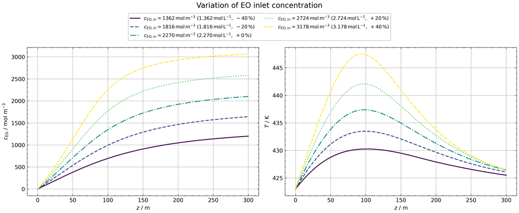

```python
# EO inlet concentration variation

c_EO_in_rel_changes = np.array([-40, -20, 0, 20, 40])       # relative change, %
c_EO_in_values = c_EO_in * (1 + c_EO_in_rel_changes / 100) # EO inlet concentrations, mol m^-3

# Solve PFTR for all EO inlet concentrations

concentration_variation_results = {}

for c_EO_in_current in c_EO_in_values:

    y0 = np.array([
        c_EO_in_current,        # initial EO concentration, mol m^-3
        c_EG_in,                # initial EG concentration, mol m^-3
        T_in                    # initial temperature, K
    ])

    solution = solve_ivp(
        fun=pftr,
        t_span=(0.0, L),
        y0=y0,
        t_eval=z_eval,
        method="RK45"
    )

    concentration_variation_results[c_EO_in_current] = solution

# Plot product concentration and temperature profiles for EO inlet concentration variation

fig, axes = plt.subplots(1, 2, figsize=(12, 5), dpi=500)

fig.suptitle(
    "Variation of EO inlet concentration",
    fontsize=12
)

colors = plt.cm.viridis(np.linspace(0, 1, len(c_EO_in_values)))
linestyles = ["-", "--", "-.", ":", (0, (3, 1, 1, 1))]

for color, linestyle, c_EO_in_current, rel_change in zip(
    colors,
    linestyles,
    c_EO_in_values,
    c_EO_in_rel_changes
):

    solution = concentration_variation_results[c_EO_in_current]

    z = solution.t              # axial reactor coordinate, m
    c_EG = solution.y[1]        # EG concentration, mol m^-3
    T = solution.y[2]           # temperature, K

    label = (
        rf"$c_{{\mathrm{{EO}},\mathrm{{in}}}} = {c_EO_in_current:.0f}\,\mathrm{{mol\,m^{{-3}}}}$ "
        rf"$({c_EO_in_current / 1000:.3f}\,\mathrm{{mol\,L^{{-1}}}},\ {rel_change:+.0f}\,\%)$"
    )

    axes[0].plot(z, c_EG, color=color, linestyle=linestyle)
    axes[1].plot(z, T, color=color, linestyle=linestyle)

    axes[0].plot([], [], label=label, color=color, linestyle=linestyle)

axes[0].set_xlabel(r"$z$ / m")
axes[0].set_ylabel(r"$c_{\mathrm{EG}}$ / mol m$^{-3}$")

axes[1].set_xlabel(r"$z$ / m")
axes[1].set_ylabel(r"$T$ / K")

for ax in axes:
    ax.grid(True)

handles, labels = axes[0].get_legend_handles_labels()

fig.legend(
    handles,
    labels,
    loc="upper center",
    ncol=2,
    fontsize=8,
    bbox_to_anchor=(0.5, 0.94)
)

plt.tight_layout(rect=[0, 0, 1, 0.86])
plt.show()
```

**Figure 9:** Concentration and temperature profiles along the PFTR for varied $\mathrm{EO}$ inlet concentrations of $1362\,\mathrm{mol\,m^{-3}}$, $1816\,\mathrm{mol\,m^{-3}}$, $2270\,\mathrm{mol\,m^{-3}}$, $2724\,\mathrm{mol\,m^{-3}}$ and $3178\,\mathrm{mol\,m^{-3}}$. The left plot shows the formation of $\mathrm{EG}$ along the reactor length, while the right plot shows the corresponding temperature profiles.

Higher $\mathrm{EO}$ inlet concentrations lead to steeper $\mathrm{EG}$ concentration profiles because more $\mathrm{EO}$ is available for reaction. As a result, the formation of $\mathrm{EG}$ increases more strongly along the reactor length. Lower inlet concentrations show the opposite behaviour, with flatter concentration profiles and lower final $\mathrm{EG}$ concentrations.

```python
# Create sorted Markdown table for outlet conversion

markdown_table = """
**Table 8:** Outlet conversion of varied EO inlet concentrations

| Case | Relative change / % | $c_{\\mathrm{EO,in}}\\,/\\,\\mathrm{mol\\,m^{-3}}$ | $X_{\\mathrm{EO,out}}\\,/\\,-$ |
| ---: | ---: | ---: | ---: |
"""

for case, (rel_change, c_EO_in_current) in enumerate(
    sorted(zip(c_EO_in_rel_changes, c_EO_in_values), key=lambda x: x[1]),
    start=1
):

    solution = concentration_variation_results[c_EO_in_current]

    c_EO_out = solution.y[0, -1]                                      # outlet EO concentration, mol m^-3
    X_EO_out = calculate_conversion(c_EO_out, c_EO_0=c_EO_in_current) # outlet EO conversion, -

    markdown_table += (
        f"| {case} | "
        f"{rel_change:+.0f} | "
        f"{c_EO_in_current:.0f} | "
        f"{X_EO_out:.4f} |\n"
    )

display(Markdown(markdown_table))
```

**Table 8:** Outlet conversion of varied EO inlet concentrations

| Case | Relative change / % | $c_{\mathrm{EO,in}}\,/\,\mathrm{mol\,m^{-3}}$ | $X_{\mathrm{EO,out}}\,/\,-$ |
| --- | --- | --- | --- |
| 1 | -40 | 1362 | 0.8810 |
| 2 | -20 | 1816 | 0.9040 |
| 3 | +0 | 2270 | 0.9260 |
| 4 | +20 | 2724 | 0.9472 |
| 5 | +40 | 3178 | 0.9640 |

The increased reaction intensity is also reflected in the outlet conversion. With increasing $\mathrm{EO}$ inlet concentration, the conversion rises from $0.8810$ at $1362\,\mathrm{mol\,m^{-3}}$ to $0.9640$ at $3178\,\mathrm{mol\,m^{-3}}$. This shows that the higher reactant availability leads to stronger $\mathrm{EO}$ consumption along the reactor length, while the reactor remains thermally controlled in the investigated range.

For the assumed base inlet concentration, a higher conversion could also be achieved by adjusting other process parameters, such as the inlet temperature or the wall temperature of the reactor.

### 4.5 Influence of Flow Velocity

The flow velocity affects both the residence time and the reactor throughput. A higher flow velocity reduces the residence time inside the PFTR, which can lower conversion. At the same time, the total volume flow increases, so more reactant is fed through the reactor per time.

The residence time is calculated from:

\begin{equation} \tau = \frac{L_{\mathrm{R}}}{u} \tag{54} \end{equation}

The total volume flow through the tubular reactor follows from the cross-sectional area:

\begin{equation} \dot{V} = u A_{\mathrm{R}} = u \frac{\pi d_{\mathrm{R}}^2}{4} \tag{55} \end{equation}

The inlet molar flow of $\mathrm{EO}$ is calculated from the inlet concentration and the total volume flow:

\begin{equation} \dot{n}_{\mathrm{EO,in}} = c_{\mathrm{EO,in}}\dot{V} \tag{56} \end{equation}

For complete conversion, the maximum possible $\mathrm{EG}$ molar flow is equal to the $\mathrm{EO}$ inlet molar flow because of the 1:1 stoichiometry:

\begin{equation} \dot{n}_{\mathrm{EG,out,max}} = \dot{n}_{\mathrm{EO,in}} \tag{57} \end{equation}

The calculations are based on the initial reactor diameter $d_{\mathrm{R}}=0.03~\mathrm{m}$, reactor length $L_{\mathrm{R}}=300~\mathrm{m}$ and $\mathrm{EO}$ inlet concentration $c_{\mathrm{EO,in}}=2270~\mathrm{mol\,m^{-3}}$.

**Table 9:** Residence time, volume flow and molar flow for varied flow velocities.

| Flow velocity / m s⁻¹ | Residence time / s | Volume flow / L min⁻¹ | EO inlet molar flow / mol s⁻¹ |
| --- | --- | --- | --- |
| 0.5 | 600 | 21.21 | 0.802 |
| 1.0 | 300 | 42.41 | 1.605 |
| 2.0 | 150 | 84.82 | 3.209 |
| 5.0 | 60 | 212.06 | 8.023 |

#### Flow Velocity and Heat-Transfer Coefficient are Coupled

The flow velocity influences the PFTR in two different ways. First, a higher flow velocity reduces the residence time inside the reactor, as already described by eq. (54). This can lower the conversion because the reaction mixture has less time to react.

Second, the flow velocity also affects the heat-transfer coefficient. In forced convection, higher flow velocities increase turbulence and therefore improve heat transfer at the reactor wall. Thus, the heat-transfer coefficient should not necessarily be treated as constant when the flow velocity is varied.

For turbulent flow in a circular tube, the Dittus-Boelter correlation can be used as an approximation:

\begin{equation} Nu = 0.023\,Re^{0.8}Pr^n \tag{58} \end{equation}

Here, $Nu$ is the Nusselt number, $Re$ is the Reynolds number and $Pr$ is the Prandtl number. The exponent $n$ depends on the thermal boundary condition and is commonly chosen depending on whether the fluid is heated or cooled.

The Reynolds number is defined as:

\begin{equation} Re = \frac{\rho u d_{\mathrm{R}}}{\eta} \tag{59} \end{equation}

Here, $\rho$ is the fluid density, $u$ is the flow velocity, $d_{\mathrm{R}}$ is the reactor diameter and $\eta$ is the dynamic viscosity.

The Prandtl number is defined as:

\begin{equation} Pr = \frac{c_p \eta}{\lambda} \tag{60} \end{equation}

Here, $c_p$ is the specific heat capacity, $\eta$ is the dynamic viscosity and $\lambda$ is the thermal conductivity of the reaction mixture.

The heat-transfer coefficient follows from the Nusselt number:

\begin{equation} h_{\mathrm{wall}} = \frac{Nu\,\lambda}{d_{\mathrm{R}}} \tag{61} \end{equation}

Here, $h_{\mathrm{wall}}$ is the heat-transfer coefficient at the reactor wall.

If the reactor diameter and fluid properties are assumed to be constant, the Reynolds number is mainly influenced by the flow velocity. Therefore, the heat-transfer coefficient can be scaled relative to the initial assignment value:

\begin{equation} h_{\mathrm{wall}}(u) = h_{\mathrm{wall},0} \left(\frac{u}{u_0}\right)^{0.8} \tag{62} \end{equation}

Here, $h_{\mathrm{wall},0}$ is the initial heat-transfer coefficient at the initial flow velocity $u_0$.

In this study, two cases are considered to separate the effects of flow velocity.

#### Case A: Constant Heat-Transfer Coefficient

In Case A, the flow velocity is varied while the heat-transfer coefficient is kept constant at the initial assignment value. This case isolates the residence-time effect. A higher flow velocity decreases the residence time and is therefore expected to reduce conversion. The cooling performance itself is not changed in this case.

#### Case B: Velocity-Dependent Heat-Transfer Coefficient

In Case B, the heat-transfer coefficient is adapted according to eq. (62). This represents the more realistic case, because an increased flow velocity also improves forced convective heat transfer. Thus, increasing the flow velocity has two competing effects: the residence time decreases, which can reduce conversion, while the heat-transfer coefficient increases, which improves heat removal and can reduce the maximum reactor temperature.

To justify the use of the Dittus-Boelter correlation, the Reynolds number is calculated for the lowest investigated flow velocity. If the flow is already turbulent at $u=0.5\,\mathrm{m\,s^{-1}}$, all higher velocities are also in the turbulent regime.

For the calculation, $\rho = 1000\,\mathrm{kg\,m^{-3}}$, $u = 0.5\,\mathrm{m\,s^{-1}}$, $d_{\mathrm{R}} = 0.03\,\mathrm{m}$ and $\eta = 1.0\cdot10^{-3}\,\mathrm{Pa\,s}$ are used. Substitution into the Reynolds number definition gives:

\begin{equation} Re(u=0.5\,\mathrm{m\,s^{-1}}) = \frac{ 1000\,\mathrm{kg\,m^{-3}} \cdot 0.5\,\mathrm{m\,s^{-1}} \cdot 0.03\,\mathrm{m} }{ 1.0\cdot10^{-3}\,\mathrm{Pa\,s} } = 1.5\cdot10^{4} \tag{63} \end{equation}

The calculated Reynolds number is clearly above the common turbulent threshold of $Re>4000$. Therefore, the flow is already turbulent at the lowest investigated flow velocity. Since all other investigated velocities are higher, the complete velocity range can be considered turbulent. Thus, the Dittus-Boelter correlation is suitable as an approximate description of the velocity-dependent heat-transfer coefficient in this sensitivity study.

##### 4.5.1 Case A: Constant heat transfer coefficient - Influence of residence time

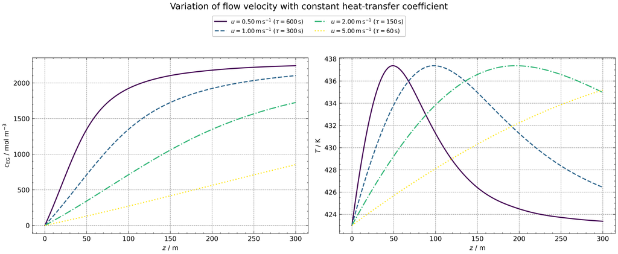

```python
# Flow velocity variation: Case A with constant heat-transfer coefficient

u_values = np.array([0.5, 1.0, 2.0, 5.0])  # fluid velocities, m s^-1

u_base = u                         # base fluid velocity, m s^-1
h_wall_base = h_wall               # base heat-transfer coefficient, J s^-1 m^-2 K^-1

velocity_variation_results_A = {}

for u_current in u_values:

    u = u_current                  # overwrite fluid velocity, m s^-1
    h_wall = h_wall_base           # keep heat-transfer coefficient constant

    y0 = np.array([
        c_EO_in,                   # initial EO concentration, mol m^-3
        c_EG_in,                   # initial EG concentration, mol m^-3
        T_in                       # initial temperature, K
    ])

    solution = solve_ivp(
        fun=pftr,
        t_span=(0.0, L),
        y0=y0,
        t_eval=z_eval,
        method="RK45"
    )

    velocity_variation_results_A[u_current] = solution

# Restore base values

u = u_base
h_wall = h_wall_base

# Plot product concentration and temperature profiles for Case A

fig, axes = plt.subplots(1, 2, figsize=(12, 5), dpi=500)

fig.suptitle(
    "Variation of flow velocity with constant heat-transfer coefficient",
    fontsize=12
)

colors = plt.cm.viridis(np.linspace(0, 1, len(u_values)))
linestyles = ["-", "--", "-.", ":"]

for color, linestyle, u_current in zip(colors, linestyles, u_values):

    solution = velocity_variation_results_A[u_current]

    z = solution.t                 # axial reactor coordinate, m
    c_EG = solution.y[1]           # EG concentration, mol m^-3
    T = solution.y[2]              # temperature, K

    tau_current = L / u_current    # residence time, s

    label = (
        rf"$u = {u_current:.2f}\,\mathrm{{m\,s^{{-1}}}}$ "
        rf"$(\tau = {tau_current:.0f}\,\mathrm{{s}})$"
    )

    axes[0].plot(z, c_EG, color=color, linestyle=linestyle)
    axes[1].plot(z, T, color=color, linestyle=linestyle)

    axes[0].plot([], [], label=label, color=color, linestyle=linestyle)

axes[0].set_xlabel(r"$z$ / m")
axes[0].set_ylabel(r"$c_{\mathrm{EG}}$ / mol m$^{-3}$")

axes[1].set_xlabel(r"$z$ / m")
axes[1].set_ylabel(r"$T$ / K")

for ax in axes:
    ax.grid(True)

handles, labels = axes[0].get_legend_handles_labels()

fig.legend(
    handles,
    labels,
    loc="upper center",
    ncol=2,
    fontsize=8,
    bbox_to_anchor=(0.5, 0.94)
)

plt.tight_layout(rect=[0, 0, 1, 0.86])
plt.show()
```

**Figure 10:** Concentration- and Temperature-profiles for varied flow velocity at constant heat transfer coefficient

In Case A, the heat-transfer coefficient is kept constant while the flow velocity is varied. The results are shown in Figure 10. Increasing the flow velocity reduces the residence time in the reactor. According to eq. (54), a higher velocity directly lowers the residence time and therefore reduces the time available for $\mathrm{EO}$ hydrolysis. This is consistent with the reaction rate expression from eq. (53), since the reaction can only proceed as long as $\mathrm{EO}$ remains inside the reactor.

As a result, lower flow velocities lead to steeper $\mathrm{EG}$ concentration profiles and higher outlet concentrations, while higher flow velocities result in shallower concentration profiles. At high flow velocity, the reaction mixture passes through the reactor faster, so less $\mathrm{EO}$ is converted within the same reactor length. For the highest investigated flow velocity, the conversion is therefore comparatively low, indicating that the reactor length is not sufficient to reach high conversion under these conditions.

The temperature profiles show that the position of the temperature maximum shifts with flow velocity. At lower flow velocities, the reaction proceeds faster with respect to the reactor length, so the temperature maximum occurs closer to the inlet. At higher flow velocities, the temperature maximum is shifted further downstream. For the highest flow velocity, the maximum is reached at the reactor outlet, which confirms that the reaction is still progressing at the end of the reactor. However, the maximum temperature remains constant in this case. This can be explained by the energy balance: the heat-transfer coefficient is fixed, so the cooling capacity per wall area does not change. Only the spatial distribution of heat generation changes due to the residence-time effect.

##### 4.5.2 Case B: Varied heat transfer coefficient - Influence of increased flowrate

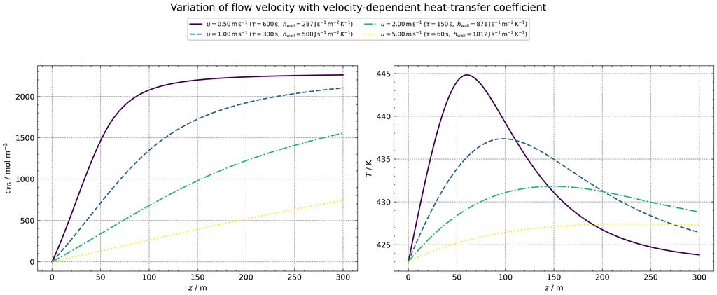

```python
# Flow velocity variation: Case B with velocity-dependent heat-transfer coefficient

u_values = np.array([0.5, 1.0, 2.0, 5.0])  # fluid velocities, m s^-1

u_base = u                         # base fluid velocity, m s^-1
h_wall_base = h_wall               # base heat-transfer coefficient, J s^-1 m^-2 K^-1

velocity_variation_results_B = {}
h_wall_values_B = {}

for u_current in u_values:

    u = u_current                                      # overwrite fluid velocity, m s^-1
    h_wall = h_wall_base * (u_current / u_base)**0.8   # adapted heat-transfer coefficient, J s^-1 m^-2 K^-1

    y0 = np.array([
        c_EO_in,                   # initial EO concentration, mol m^-3
        c_EG_in,                   # initial EG concentration, mol m^-3
        T_in                       # initial temperature, K
    ])

    solution = solve_ivp(
        fun=pftr,
        t_span=(0.0, L),
        y0=y0,
        t_eval=z_eval,
        method="RK45"
    )

    velocity_variation_results_B[u_current] = solution
    h_wall_values_B[u_current] = h_wall

# Restore base values

u = u_base
h_wall = h_wall_base

# Plot product concentration and temperature profiles for Case B

fig, axes = plt.subplots(1, 2, figsize=(12, 5), dpi=500)

fig.suptitle(
    "Variation of flow velocity with velocity-dependent heat-transfer coefficient",
    fontsize=12
)

colors = plt.cm.viridis(np.linspace(0, 1, len(u_values)))
linestyles = ["-", "--", "-.", ":"]

for color, linestyle, u_current in zip(colors, linestyles, u_values):

    solution = velocity_variation_results_B[u_current]
    h_wall_current = h_wall_values_B[u_current]

    z = solution.t                 # axial reactor coordinate, m
    c_EG = solution.y[1]           # EG concentration, mol m^-3
    T = solution.y[2]              # temperature, K

    tau_current = L / u_current    # residence time, s

    label = (
        rf"$u = {u_current:.2f}\,\mathrm{{m\,s^{{-1}}}}$ "
        rf"$(\tau = {tau_current:.0f}\,\mathrm{{s}},\ "
        rf"h_\mathrm{{wall}} = {h_wall_current:.0f}\,\mathrm{{J\,s^{{-1}}\,m^{{-2}}\,K^{{-1}}}})$"
    )

    axes[0].plot(z, c_EG, color=color, linestyle=linestyle)
    axes[1].plot(z, T, color=color, linestyle=linestyle)

    axes[0].plot([], [], label=label, color=color, linestyle=linestyle)

axes[0].set_xlabel(r"$z$ / m")
axes[0].set_ylabel(r"$c_{\mathrm{EG}}$ / mol m$^{-3}$")

axes[1].set_xlabel(r"$z$ / m")
axes[1].set_ylabel(r"$T$ / K")

for ax in axes:
    ax.grid(True)

handles, labels = axes[0].get_legend_handles_labels()

fig.legend(
    handles,
    labels,
    loc="upper center",
    ncol=2,
    fontsize=7,
    bbox_to_anchor=(0.5, 0.94)
)

plt.tight_layout(rect=[0, 0, 1, 0.86])
plt.show()
```

**Figure 11:** Concentration- and Temperature-profiles for varied flow velocity. Heat transfer coefficient is varied by changed flowrate

```python
# Create Markdown table for outlet conversion comparison of Case A and Case B

markdown_table = """
**Table 10:** Outlet conversion for varied flow velocity in Case A and Case B

| $u\\,/\\,\\mathrm{m\\,s^{-1}}$ | $h_{\\mathrm{wall}}\\,/\\,\\mathrm{J\\,s^{-1}\\,m^{-2}\\,K^{-1}}$ Case A | $X_{\\mathrm{EO},\\mathrm{out}}\\,/\\,-$ Case A | $h_{\\mathrm{wall}}\\,/\\,\\mathrm{J\\,s^{-1}\\,m^{-2}\\,K^{-1}}$ Case B | $X_{\\mathrm{EO},\\mathrm{out}}\\,/\\,-$ Case B |
| ---: | ---: | ---: | ---: | ---: |
"""

for u_current in sorted(u_values):

    solution_A = velocity_variation_results_A[u_current]
    solution_B = velocity_variation_results_B[u_current]

    c_EO_out_A = solution_A.y[0, -1]              # outlet EO concentration, mol m^-3
    c_EO_out_B = solution_B.y[0, -1]              # outlet EO concentration, mol m^-3

    X_EO_out_A = calculate_conversion(c_EO_out_A) # outlet EO conversion, -
    X_EO_out_B = calculate_conversion(c_EO_out_B) # outlet EO conversion, -

    h_wall_A = h_wall_base                        # heat-transfer coefficient, J s^-1 m^-2 K^-1
    h_wall_B = h_wall_values_B[u_current]         # heat-transfer coefficient, J s^-1 m^-2 K^-1

    markdown_table += (
        f"| {u_current:.1f} | "
        f"{h_wall_A:.0f} | "
        f"{X_EO_out_A:.4f} | "
        f"{h_wall_B:.0f} | "
        f"{X_EO_out_B:.4f} |\n"
    )

display(Markdown(markdown_table))
```

**Table 10:** Outlet conversion for varied flow velocity in Case A and Case B

| $u\,/\,\mathrm{m\,s^{-1}}$ | $h_{\mathrm{wall}}\,/\,\mathrm{J\,s^{-1}\,m^{-2}\,K^{-1}}$ Case A | $X_{\mathrm{EO},\mathrm{out}}\,/\,-$ Case A | $h_{\mathrm{wall}}\,/\,\mathrm{J\,s^{-1}\,m^{-2}\,K^{-1}}$ Case B | $X_{\mathrm{EO},\mathrm{out}}\,/\,-$ Case B |
| --- | --- | --- | --- | --- |
| 0.5 | 500 | 0.9873 | 287 | 0.9955 |
| 1.0 | 500 | 0.9260 | 500 | 0.9260 |
| 2.0 | 500 | 0.7597 | 871 | 0.6854 |
| 5.0 | 500 | 0.3758 | 1812 | 0.3270 |

In Case B, the heat-transfer coefficient is adapted according to the Dittus-Boelter scaling in eq. (62). The corresponding values are listed in Table 10. As the flow velocity increases from $0.5\,\mathrm{m\,s^{-1}}$ to $5.0\,\mathrm{m\,s^{-1}}$, the heat-transfer coefficient rises from $287\,\mathrm{J\,s^{-1}\,m^{-2}\,K^{-1}}$ to $1812\,\mathrm{J\,s^{-1}\,m^{-2}\,K^{-1}}$. At the same time, the residence time decreases, so the reaction mixture remains inside the reactor for a shorter time.

The outlet conversions show that the residence-time effect dominates over the improved heat removal. In Case B, the conversion decreases from $0.9955$ at $0.5\,\mathrm{m\,s^{-1}}$ to $0.3270$ at $5.0\,\mathrm{m\,s^{-1}}$. This confirms that higher flow velocities strongly reduce the available reaction time and therefore lower the conversion of $\mathrm{EO}$, even though the heat-transfer coefficient increases.

Compared to Case A, the conversion in Case B is lower for velocities above $1.0\,\mathrm{m\,s^{-1}}$. This is caused by the increased heat removal at higher flow velocities. The stronger cooling reduces the reactor temperature, which lowers the temperature-dependent reaction rate and further decreases $\mathrm{EO}$ conversion. Therefore, Case B combines two effects: shorter residence time and stronger cooling. Both effects reduce the outlet conversion at high flow velocity.

Since both cases show the same overall conversion trend, the simplified assumption of a constant heat-transfer coefficient in Case A is acceptable when the main focus is the effect of flow velocity on $\mathrm{EO}$ conversion. However, the temperature profiles differ more clearly between the two cases. The velocity-dependent heat-transfer coefficient changes both the absolute value and the position of the temperature maximum. Therefore, Case B is more relevant for evaluating thermal safety, because hot-spot formation and maximum reactor temperature depend directly on the heat-transfer behaviour.

The heat-transfer coefficients in Case B should not be interpreted as absolute Dittus-Boelter values. The base value of $h_{\mathrm{wall}}=500\,\mathrm{J\,s^{-1}\,m^{-2}\,K^{-1}}$ at $u=1.0\,\mathrm{m\,s^{-1}}$ was taken from the initial parameter set and not calculated from the Dittus-Boelter correlation. Therefore, the scaling is used only to represent the qualitative dependence of heat transfer on flow velocity, while the resulting values should not be used for detailed quantitative heat-transfer design.

Both Case A and Case B show the same general trend: a sufficiently high residence time is required to achieve proper $\mathrm{EO}$ conversion. Increasing the flow velocity increases the reactor throughput, but it also lowers the residence time and therefore reduces conversion.

For industrial operation, this means that changes in flow rate can directly affect the outlet concentration. If a fixed outlet concentration is required, variations in flow rate need to be compensated by adapting other operating parameters, such as additional heating or cooling, or by changing the reactor temperature level to maintain the desired conversion.

### 4.6 Residence-Time Behaviour and Fixed Process Parameter Selection

After the individual process parameters have been investigated, the reactor behaviour is evaluated using the Damköhler number. The previous parameter studies showed that the residence time has a strong influence on $\mathrm{EO}$ conversion. This effect was especially visible in the flow-velocity study, where higher flow velocities led to shorter residence times and therefore lower outlet conversions.

The Damköhler number combines the residence time and the characteristic reaction rate into one dimensionless number:

\begin{equation} Da_{\mathrm{I}} = \frac{\tau r_{\mathrm{in}}}{c_{\mathrm{EO,in}}} \tag{64} \end{equation}

With the residence time of the PFTR,

\begin{equation} \tau = \frac{L_{\mathrm{R}}}{u} \tag{65} \end{equation}

the Damköhler number directly links the reactor length, flow velocity and reaction kinetics. A low Damköhler number indicates that the residence time is too short compared to the reaction time. In this case, only limited $\mathrm{EO}$ conversion is expected. A high Damköhler number indicates that the reaction mixture remains in the reactor long enough to achieve high conversion.

To investigate this behaviour, the outlet conversion is plotted as a function of the Damköhler number.

\begin{equation} X_{\mathrm{EO,out}} = \frac{c_{\mathrm{EO,in}}-c_{\mathrm{EO,out}}} {c_{\mathrm{EO,in}}} \tag{66} \end{equation}

This analysis is used to select a fixed process parameter set for the following reactor-geometry study. The selected set should provide a sufficiently high Damköhler number to achieve high $\mathrm{EO}$ conversion, while avoiding excessive maximum reactor temperatures.

The selected operating point is also compared with literature expectations for tubular $\mathrm{EO}$ hydrolysis.

```
Base Damköhler number: Da_I = 1.6712e+00
```

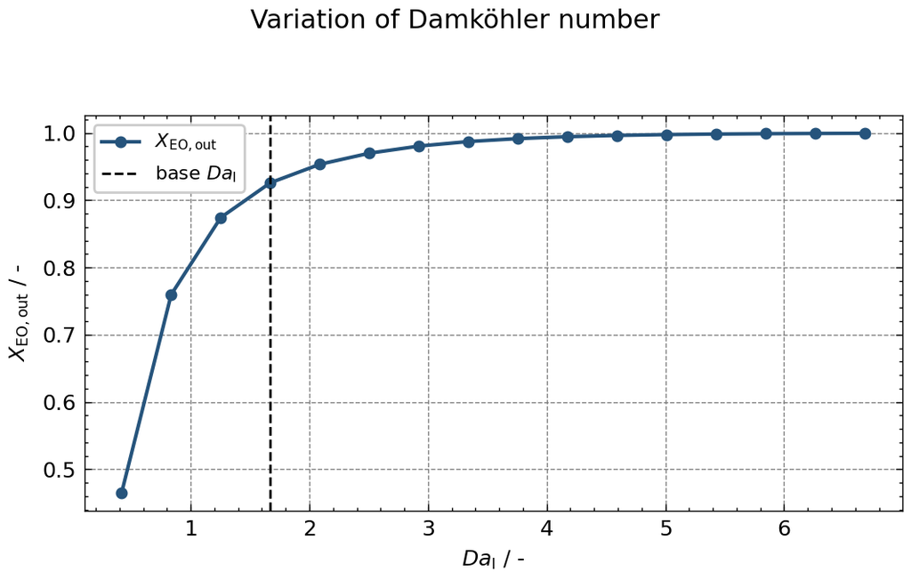

```python
# Damköhler number study with linear Da scaling

r_in = kinetics(c_EO_in, T_in)              # inlet reaction rate, mol m^-3 s^-1
tau_base = L / u                            # base residence time, s
Da_base = tau_base * r_in / c_EO_in         # base Damköhler number, -

print(f"Base Damköhler number: Da_I = {Da_base:.4e}")

# Linear scaling of the base Damköhler number

Da_factors = np.linspace(0.25, 4.0, 16)     # linear scaling factors, -
Da_values = Da_base * Da_factors            # varied Damköhler numbers, -

Da_results = {}

u_base = u
h_wall_base = h_wall

for Da_current in Da_values:

    tau_current = Da_current * c_EO_in / r_in       # residence time, s
    u_current = L / tau_current                     # fluid velocity, m s^-1

    u = u_current                                   # overwrite fluid velocity, m s^-1
    h_wall = h_wall_base                            # keep heat-transfer coefficient constant

    y0 = np.array([
        c_EO_in,                                    # initial EO concentration, mol m^-3
        c_EG_in,                                    # initial EG concentration, mol m^-3
        T_in                                        # initial temperature, K
    ])

    solution = solve_ivp(
        fun=pftr,
        t_span=(0.0, L),
        y0=y0,
        t_eval=z_eval,
        method="RK45"
    )

    Da_results[Da_current] = {
        "solution": solution,
        "tau": tau_current,
        "u": u_current
    }

# Restore base values

u = u_base
h_wall = h_wall_base

# Evaluate outlet conversion and maximum temperature

Da_plot = []
X_EO_out_plot = []
T_max_plot = []
u_plot = []
tau_plot = []

for Da_current in sorted(Da_results.keys()):

    solution = Da_results[Da_current]["solution"]

    c_EO_out = solution.y[0, -1]                    # outlet EO concentration, mol m^-3
    T_profile = solution.y[2]                       # temperature profile, K

    X_EO_out = calculate_conversion(c_EO_out)       # outlet EO conversion, -
    T_max = np.max(T_profile)                       # maximum reactor temperature, K

    Da_plot.append(Da_current)
    X_EO_out_plot.append(X_EO_out)
    T_max_plot.append(T_max)
    u_plot.append(Da_results[Da_current]["u"])
    tau_plot.append(Da_results[Da_current]["tau"])

Da_plot = np.array(Da_plot)
X_EO_out_plot = np.array(X_EO_out_plot)
T_max_plot = np.array(T_max_plot)
u_plot = np.array(u_plot)
tau_plot = np.array(tau_plot)

# Plot outlet conversion over Damköhler number

fig, ax = plt.subplots(figsize=(5.5, 3.5), dpi=200)

fig.suptitle(
    "Variation of Damköhler number",
    fontsize=11
)

ax.plot(
    Da_plot,
    X_EO_out_plot,
    marker="o",
    markersize=4,
    color=ICIWcolors.CERULEAN,
    label=r"$X_{\mathrm{EO,out}}$"
)

ax.axvline(
    Da_base,
    color="black",
    linestyle="--",
    linewidth=1,
    label=r"base $Da_{\mathrm{I}}$"
)

ax.set_xlabel(r"$Da_{\mathrm{I}}$ / -")
ax.set_ylabel(r"$X_{\mathrm{EO},\mathrm{out}}$ / -")
ax.legend(fontsize=8)
ax.grid(True)

plt.tight_layout(rect=[0, 0, 1, 0.92])
plt.show()
```

**Figure 12:** $\mathrm{EO}$ outlet conversion as a function of the Damköhler number $Da_\mathrm{I}$. The dashed vertical line marks the base Damköhler number of the initial parameter set.

The outlet conversion increases with increasing Damköhler number. This is expected because a higher $Da_{\mathrm{I}}$ represents a higher residence time relative to the characteristic reaction time. Therefore, the reaction mixture remains longer inside the reactor and more $\mathrm{EO}$ can be converted to $\mathrm{EG}$.

At low Damköhler numbers, the conversion is clearly limited. In this region, the residence time is too short for complete $\mathrm{EO}$ conversion. With increasing $Da_{\mathrm{I}}$, the conversion rises strongly until it approaches a plateau close to complete conversion. This indicates that beyond a certain residence time, further increasing $Da_{\mathrm{I}}$ gives only a small additional conversion benefit.

This behaviour is consistent with the results from Chapter 4.5, where lower flow velocities led to higher conversion due to longer residence times. Therefore, the Damköhler number confirms that a sufficiently high residence time is required for proper $\mathrm{EO}$ conversion.

For further investigation, a fixed set of process parameters has to be defined. Based on the previous parameter studies, high $\mathrm{EO}$ conversion can be achieved when the reactor provides a sufficiently high residence time. This was also confirmed by the Damköhler number study, where the outlet conversion increased strongly with increasing $Da_{\mathrm{I}}$ and approached a plateau close to complete conversion.

The base reactor has a residence time of:

\begin{equation} \tau = \frac{L_{\mathrm{R}}}{u} = \frac{300\,\mathrm{m}}{1.0\,\mathrm{m\,s^{-1}}} = 300\,\mathrm{s} \tag{67} \end{equation}

This residence time is selected for the following investigation because it already provides high conversion under the investigated conditions. In the base polytropic case, the outlet conversion reaches $X_{\mathrm{EO,out}}=0.9258$. Under adiabatic operation, complete $\mathrm{EO}$ conversion is achieved at the same residence time, while the maximum reactor temperature remains below 473 K.

The selected operating temperature is also within the range reported in literature. According to Falcke et al. [3], industrial glycol production is carried out by reacting $\mathrm{EO}$ with water at elevated temperatures, typically between 150 °C and 250 °C. This corresponds to:

\begin{equation} T = 423\text{--}523\,\mathrm{K} \tag{68} \end{equation}

Therefore, the selected inlet temperature of $T_{\mathrm{in}}=423\,\mathrm{K}$ is at the lower boundary of the reported industrial range. The maximum temperature of the adiabatic case remains below 473 K and is therefore still within the literature-based operating range.

The assumption of water being present in excess is also consistent with literature. van Hal et al. [2] state that conventional $\mathrm{EO}$ hydration uses a large excess of water, typically 20–25 mol water per mol $\mathrm{EO}$, to obtain a high selectivity towards monoethylene glycol.

\begin{equation} \frac{n_{\mathrm{H_2O}}}{n_{\mathrm{EO}}} = 20\text{--}25 \tag{69} \end{equation}

Thus, water can be assumed to be present in large excess, while $\mathrm{EO}$ is treated as the limiting reactant. This supports the simplified first-order rate expression with respect to $\mathrm{EO}$ used in the model.

Therefore, the selected residence time of 300 s is considered sufficient for high $\mathrm{EO}$ conversion. Since the adiabatic temperature rise remains within the literature-based operating range, the reactor is further evaluated under adiabatic operation as a limiting and technically favourable case without additional heat removal.

**Table 11:** Selected process parameters for the following reactor study.

| Quantity | Symbol | Selected value |
| --- | --- | --- |
| Fluid velocity | u | 1.0 m s⁻¹ |
| Reactor length | Lᵣ | 300 m |
| Residence time | τ | 300 s |
| Tube diameter | dᵣ | 0.03 m |
| EO inlet concentration | c_EO,in | 2.27 · 10³ mol m⁻³ |
| EG inlet concentration | c_EG,in | 0 mol m⁻³ |
| Inlet temperature | T_in | 423 K |
| Wall temperature | T_wall | 423 K |
| Heat-transfer mode | - | adiabatic |
| Stanton number | St | 0 |

The volumetric throughput is calculated from the fluid velocity and the tube cross-sectional area:

\begin{equation} \dot{V} = u A_{\mathrm{R}} = u \frac{\pi d_{\mathrm{R}}^2}{4} \tag{70} \end{equation}

With $u=1.0\,\mathrm{m\,s^{-1}}$ and $d_{\mathrm{R}}=0.03\,\mathrm{m}$, this gives:

\begin{equation} \dot{V} = 1.0 \cdot \frac{\pi \cdot (0.03)^2}{4} = 7.07 \cdot 10^{-4}\,\mathrm{m^3\,s^{-1}} \tag{71} \end{equation}

The corresponding $\mathrm{EO}$ inlet molar flow is:

\begin{equation} \dot{n}_{\mathrm{EO,in}} = c_{\mathrm{EO,in}}\dot{V} = 2.27\cdot10^3 \cdot 7.07\cdot10^{-4} = 1.60\,\mathrm{mol\,s^{-1}} \tag{72} \end{equation}

For the adiabatic operating point, complete $\mathrm{EO}$ conversion is reached. Since the reaction stoichiometry between $\mathrm{EO}$ and $\mathrm{EG}$ is 1:1, the outlet molar flow of $\mathrm{EG}$ is:

\begin{equation} \dot{n}_{\mathrm{EG,out}} = X_{\mathrm{EO,out}}\dot{n}_{\mathrm{EO,in}} = 1.0000 \cdot 1.60 = 1.60\,\mathrm{mol\,s^{-1}} \tag{73} \end{equation}

Using the molar mass of $\mathrm{EG}$,

\begin{equation} M_{\mathrm{EG}} = 62.07\,\mathrm{g\,mol^{-1}} \tag{74} \end{equation}

the mass flow of $\mathrm{EG}$ is:

\begin{equation} \dot{m}_{\mathrm{EG}} = \dot{n}_{\mathrm{EG,out}}M_{\mathrm{EG}} = 1.60 \cdot 62.07 = 99.6\,\mathrm{g\,s^{-1}} = 358.8\,\mathrm{kg\,h^{-1}} \tag{75} \end{equation}

For 8000 operating hours per year, the annual production is:

\begin{equation} m_{\mathrm{EG},a} = 358.8\,\mathrm{kg\,h^{-1}} \cdot 8000\,\mathrm{h\,a^{-1}} = 2.87\cdot10^6\,\mathrm{kg\,a^{-1}} = 2870\,\mathrm{t\,a^{-1}} \tag{76} \end{equation}

**Table 12:** Throughput and annual EG production for the selected operating point.

| Quantity | Symbol | Value |
| --- | --- | --- |
| Fluid velocity | u | 1.0 m s⁻¹ |
| Tube diameter | dᵣ | 0.03 m |
| Volumetric flow rate | V̇ | 7.07 · 10⁻⁴ m³ s⁻¹ |
| Volumetric flow rate | V̇ | 2.54 m³ h⁻¹ |
| EO inlet concentration | c_EO,in | 2.27 · 10³ mol m⁻³ |
| EO inlet molar flow | ṅ_EO,in | 1.60 mol s⁻¹ |
| EO outlet conversion | X_EO,out | 1.0000 |
| EG outlet molar flow | ṅ_EG,out | 1.60 mol s⁻¹ |
| EG mass flow | ṁ_EG | 358.8 kg h⁻¹ |
| Operating time | t_op | 8000 h a⁻¹ |
| Annual EG production | m_EG,a | 2870 t a⁻¹ |

## 5. Reactor Dimensions and Design Parameters - Design for Industrial Application

The previous investigation showed that the selected base reactor is able to achieve high $\mathrm{EO}$ conversion under the chosen operating conditions. However, the calculated annual production of $\mathrm{EG}$ for the base reactor is only 2870 t a⁻¹. This production capacity is far below the scale of industrial $\mathrm{EO}/\mathrm{EG}$ plants. Literature data show that typical large-scale plants can operate in the range of several hundred kilotonnes per year, with capacities around 500 kt a⁻¹ reported for industrial $\mathrm{EO}/\mathrm{EG}$ production sites [3].

Therefore, the following reactor design study is based on an industrial production target of:

\begin{equation} \dot{m}_{\mathrm{EG},a,\mathrm{target}} = 500\,000\,\mathrm{t\,a^{-1}} \tag{77} \end{equation}

In addition to the production target, the reactor must still provide sufficient conversion of $\mathrm{EO}$. Based on the previous Damköhler number and residence-time analysis, a high residence time is required to achieve high conversion. For the industrial design case, the minimum target conversion is therefore defined as:

\begin{equation} X_{\mathrm{EO,out}} \geq 0.90 \tag{78} \end{equation}

The aim of this chapter is to determine how the reactor dimensions and design parameters have to be adapted in order to reach an industrially relevant production capacity while maintaining at least 90% $\mathrm{EO}$ conversion. Therefore, the effects of reactor length, tube diameter and throughput are investigated with respect to conversion, residence time and annual $\mathrm{EG}$ production.

The inlet concentration of $\mathrm{EO}$ is also taken from the base case scenario. This is a reasonable assumption for the design study, since the feed to the glycol reactor can be interpreted as the aqueous output stream from an upstream $\mathrm{EO}$ production and recovery section. Therefore, the inlet concentration is kept constant at:

\begin{equation} c_{\mathrm{EO,in}} = 2.27 \cdot 10^3\,\mathrm{mol\,m^{-3}} \tag{79} \end{equation}

Keeping the inlet concentration constant allows the influence of reactor dimensions and throughput to be investigated independently from changes in feed composition. This also applies to the inlet temperature, which is kept constant at 423 K.

For the following capacity study, velocity-dependent heat-transfer coefficients according to the Dittus-Boelter scaling from Chapter 4.5 are not considered further. As discussed before, this scaling is useful for qualitative reasoning, but the resulting heat-transfer coefficients should not be interpreted as absolute design values. Therefore, the heat-transfer coefficient is not used as the main design parameter in this chapter.

Instead, the effect of residence time is investigated. For fixed reactor dimensions, the residence time is directly determined by the fluid velocity:

\begin{equation} \tau = \frac{L_{\mathrm{R}}}{u} \tag{80} \end{equation}

A higher flow velocity increases the throughput and therefore the possible annual production, but it also decreases the residence time. This can reduce the outlet conversion of $\mathrm{EO}$. Therefore, suitable flow velocities have to be identified that still achieve the required minimum conversion at the fixed reactor length.

As shown in Chapter 4.2, a high wall temperature achieves high conversion, while Chapter 4.3 indicates that adiabatic conditions are favourable for the selected reactor setup. Therefore, both cases are simulated for the maximum capacity study.

### 5.1 Maximum operational capacity of the base-case reactor

The maximum capacity of the base reactor dimensions is determined by increasing the flow velocity until the outlet conversion approaches this lower conversion limit. This allows the highest possible throughput to be estimated while keeping the reactor length and tube diameter unchanged. The inlet temperature as well as the inlet concentration are chosen as stated above

The following implementation uses the root-finding function `scipy.optimize.brentq`. This method determines the flow velocity at which the outlet conversion reaches the target value of $X_{\mathrm{EO},out}=0.90$. Therefore, the calculated velocity represents the maximum allowable velocity for the selected reactor length, because higher velocities would reduce the residence time and lead to conversions below the required 90%.

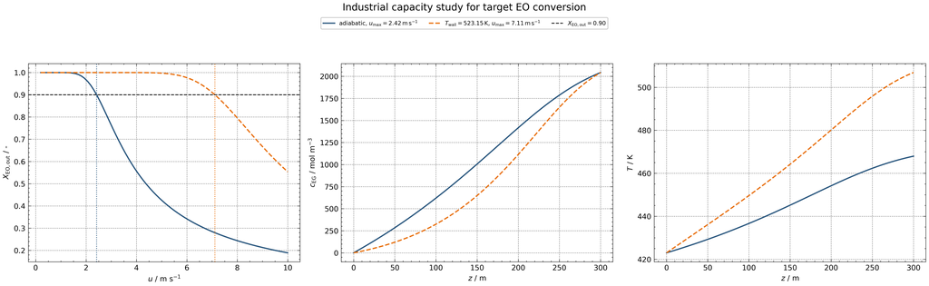

```python
# Industrial capacity study: maximum flow velocity for X_EO,out >= 0.90

X_target = 0.90                         # target EO conversion, -
T_wall_hot = 523.15                     # wall temperature, K, corresponding to 250 °C

u_base = u                              # base fluid velocity, m s^-1
h_wall_base = h_wall                    # base heat-transfer coefficient, J s^-1 m^-2 K^-1
T_wall_base = T_wall                    # base wall temperature, K

u_scan = np.linspace(0.2, 10.0, 80)     # scanned fluid velocities, m s^-1


def solve_pftr_for_design_case(u_current, h_wall_current, T_wall_current):
    """
    Solve the PFTR model for a selected design case.

    Parameters
    ----------
    u_current : float
        Fluid velocity, m s^-1
    h_wall_current : float
        Wall heat-transfer coefficient, J s^-1 m^-2 K^-1
    T_wall_current : float
        Wall temperature, K

    Returns
    -------
    solution : OdeResult
        Numerical PFTR solution.
    """
    global u, h_wall, T_wall

    u = u_current                       # overwrite fluid velocity, m s^-1
    h_wall = h_wall_current             # overwrite heat-transfer coefficient, J s^-1 m^-2 K^-1
    T_wall = T_wall_current             # overwrite wall temperature, K

    y0 = np.array([
        c_EO_in,                        # initial EO concentration, mol m^-3
        c_EG_in,                        # initial EG concentration, mol m^-3
        T_in                            # initial temperature, K
    ])

    solution = solve_ivp(
        fun=pftr,
        t_span=(0.0, L),
        y0=y0,
        t_eval=z_eval,
        method="Radau"
    )

    return solution


def calculate_outlet_conversion_for_case(u_current, h_wall_current, T_wall_current):
    """
    Calculate outlet conversion for a selected velocity and thermal case.

    Parameters
    ----------
    u_current : float
        Fluid velocity, m s^-1
    h_wall_current : float
        Wall heat-transfer coefficient, J s^-1 m^-2 K^-1
    T_wall_current : float
        Wall temperature, K

    Returns
    -------
    X_EO_out : float
        EO outlet conversion, -
    """
    solution = solve_pftr_for_design_case(
        u_current,
        h_wall_current,
        T_wall_current
    )

    c_EO_out = solution.y[0, -1]         # outlet EO concentration, mol m^-3
    X_EO_out = calculate_conversion(c_EO_out)

    return X_EO_out


design_cases = {
    "adiabatic": {
        "h_wall": 0.0,
        "T_wall": T_wall_base,
        "label": r"adiabatic"
    },
    "wall temperature 523.15 K": {
        "h_wall": h_wall_base,
        "T_wall": T_wall_hot,
        "label": r"$T_{\mathrm{wall}} = 523.15\,\mathrm{K}$"
    }
}

design_results = {}

for case_name, case_data in design_cases.items():

    h_case = case_data["h_wall"]
    T_wall_case = case_data["T_wall"]

    X_scan = []

    for u_current in u_scan:

        X_EO_out = calculate_outlet_conversion_for_case(
            u_current,
            h_case,
            T_wall_case
        )

        X_scan.append(X_EO_out)

    X_scan = np.array(X_scan)
    valid_indices = np.where(X_scan >= X_target)[0]

    if len(valid_indices) == 0:

        u_limit = np.nan
        solution_limit = None

    elif valid_indices[-1] == len(u_scan) - 1:

        u_limit = u_scan[-1]

        solution_limit = solve_pftr_for_design_case(
            u_limit,
            h_case,
            T_wall_case
        )

    else:

        idx_upper = valid_indices[-1] + 1

        u_low = u_scan[idx_upper - 1]
        u_high = u_scan[idx_upper]

        def target_function(u_current):
            return (
                calculate_outlet_conversion_for_case(
                    u_current,
                    h_case,
                    T_wall_case
                )
                - X_target
            )

        u_limit = brentq(target_function, u_low, u_high)

        solution_limit = solve_pftr_for_design_case(
            u_limit,
            h_case,
            T_wall_case
        )

    design_results[case_name] = {
        "u_scan": u_scan,
        "X_scan": X_scan,
        "u_limit": u_limit,
        "solution_limit": solution_limit,
        "h_wall": h_case,
        "T_wall": T_wall_case,
        "label": case_data["label"]
    }

# Restore base values

u = u_base
h_wall = h_wall_base
T_wall = T_wall_base

# Plot conversion scan, EG concentration profiles and temperature profiles

fig, axes = plt.subplots(1, 3, figsize=(16, 5), dpi=500)

fig.suptitle(
    "Industrial capacity study for target EO conversion",
    fontsize=12
)

colors = [ICIWcolors.CERULEAN, ICIWcolors.FLAME]
linestyles = ["-", "--"]

for color, linestyle, (case_name, result) in zip(colors, linestyles, design_results.items()):

    label = (
        result["label"]
        + rf", $u_\mathrm{{max}} = {result['u_limit']:.2f}\,\mathrm{{m\,s^{{-1}}}}$"
    )

    axes[0].plot(
        result["u_scan"],
        result["X_scan"],
        color=color,
        linestyle=linestyle,
        label=label
    )

    axes[0].axvline(
        result["u_limit"],
        color=color,
        linestyle=":",
        linewidth=1
    )

    solution = result["solution_limit"]

    z = solution.t                      # axial reactor coordinate, m
    c_EG = solution.y[1]                # EG concentration, mol m^-3
    T = solution.y[2]                   # temperature, K

    axes[1].plot(
        z,
        c_EG,
        color=color,
        linestyle=linestyle
    )

    axes[2].plot(
        z,
        T,
        color=color,
        linestyle=linestyle
    )

axes[0].axhline(
    X_target,
    color="black",
    linestyle="--",
    linewidth=1,
    label=r"$X_{\mathrm{EO,out}} = 0.90$"
)

axes[0].set_xlabel(r"$u$ / m s$^{-1}$")
axes[0].set_ylabel(r"$X_{\mathrm{EO,out}}$ / -")

axes[1].set_xlabel(r"$z$ / m")
axes[1].set_ylabel(r"$c_{\mathrm{EG}}$ / mol m$^{-3}$")

axes[2].set_xlabel(r"$z$ / m")
axes[2].set_ylabel(r"$T$ / K")

for ax in axes:
    ax.grid(True)

handles, labels = axes[0].get_legend_handles_labels()

fig.legend(
    handles,
    labels,
    loc="upper center",
    ncol=3,
    fontsize=7,
    bbox_to_anchor=(0.5, 0.94)
)

plt.tight_layout(rect=[0, 0, 1, 0.86])
plt.show()
```

**Figure 13:** Maximum-capacity comparison of the base reactor dimensions for adiabatic operation and externally heated operation at $T_\mathrm{wall}=523.15~\mathrm{K}$. The figure shows the maximum velocities required to maintain $X_{\mathrm{EO},out}=0.90$ and the corresponding $\mathrm{EG}$ concentration and temperature profiles.

```python
# Create Markdown table with limiting operating points and annual production

A_cross = np.pi * d_R**2 / 4          # tube cross-sectional area, m^2
M_EG = 62.07e-3                       # molar mass of EG, kg mol^-1
operating_hours = 8000                # annual operating time, h a^-1

markdown_table = """
**Table 13:** Maximum flow velocity for outlet conversion above 90%

| Case | $u_{\\mathrm{max}}\\,/\\,\\mathrm{m\\,s^{-1}}$ | $\\tau\\,/\\,\\mathrm{s}$ | $X_{\\mathrm{EO,out}}\\,/\\,-$ | $\\dot{m}_{\\mathrm{EG,a}}\\,/\\,\\mathrm{t\\,a^{-1}}$ | $T_{\\mathrm{max}}\\,/\\,\\mathrm{K}$ | $T_{\\mathrm{out}}\\,/\\,\\mathrm{K}$ |
| --- | ---: | ---: | ---: | ---: | ---: | ---: |
"""

for case_name, result in design_results.items():

    u_limit = result["u_limit"]
    tau_limit = L / u_limit

    solution = result["solution_limit"]

    c_EO_out = solution.y[0, -1]                 # outlet EO concentration, mol m^-3
    c_EG_out = solution.y[1, -1]                 # outlet EG concentration, mol m^-3
    X_EO_out = calculate_conversion(c_EO_out)    # outlet EO conversion, -

    V_dot = u_limit * A_cross                    # volume flow, m^3 s^-1
    n_dot_EG_out = c_EG_out * V_dot              # EG outlet molar flow, mol s^-1

    m_EG_year = (
        n_dot_EG_out
        * M_EG
        * operating_hours
        * 3600
        / 1000
    )                                            # annual EG production, t a^-1

    T_profile = solution.y[2]                    # temperature profile, K
    T_max = np.max(T_profile)                    # maximum reactor temperature, K
    T_out = T_profile[-1]                        # outlet temperature, K

    markdown_table += (
        f"| {case_name} | "
        f"{u_limit:.3f} | "
        f"{tau_limit:.1f} | "
        f"{X_EO_out:.4f} | "
        f"{m_EG_year:.1f} | "
        f"{T_max:.2f} | "
        f"{T_out:.2f} |\n"
    )

display(Markdown(markdown_table))
```

**Table 13:** Maximum flow velocity for outlet conversion above 90%

| Case | $u_{\mathrm{max}}\,/\,\mathrm{m\,s^{-1}}$ | $\tau\,/\,\mathrm{s}$ | $X_{\mathrm{EO,out}}\,/\,-$ | $\dot{m}_{\mathrm{EG,a}}\,/\,\mathrm{t\,a^{-1}}$ | $T_{\mathrm{max}}\,/\,\mathrm{K}$ | $T_{\mathrm{out}}\,/\,\mathrm{K}$ |
| --- | --- | --- | --- | --- | --- | --- |
| adiabatic | 2.417 | 124.1 | 0.9000 | 6240.1 | 467.96 | 467.96 |
| wall temperature 523.15 K | 7.110 | 42.2 | 0.9000 | 18353.7 | 506.86 | 506.86 |

Figure 13 and Table 13 show the maximum capacity of the base reactor dimensions under two thermal operating modes. The maximum flow velocity is defined by the condition that the outlet conversion must remain at least $X_{\mathrm{EO},out}=0.90$. Under adiabatic operation, this limit is reached at  
$u_\mathrm{max}=2.417~\mathrm{m\,s^{-1}}$. This corresponds to a residence time of $\tau=124.1~\mathrm{s}$ and an annual $\mathrm{EG}$ production of $6240.1~\mathrm{t\,a^{-1}}$.

For the externally heated case with $T_\mathrm{wall}=523.15~\mathrm{K}$, the maximum allowable flow velocity increases to $u_\mathrm{max}=7.110~\mathrm{m\,s^{-1}}$. The corresponding residence time decreases to only $\tau=42.2~\mathrm{s}$, while the same outlet conversion of $X_{\mathrm{EO},out}=0.90$ is still achieved. This is caused by the additional heat input from the hot reactor wall. The higher reactor temperature increases the reaction rate and compensates for the shorter residence time.

The difference is also visible in the annual production. While the adiabatic base reactor reaches $6240.1~\mathrm{t\,a^{-1}}$, the heated-wall case reaches $18353.7~\mathrm{t\,a^{-1}}$. Therefore, external heating increases the maximum capacity by approximately a factor of three compared with the adiabatic case. However, both values are still far below the industrial target of $500\,000~\mathrm{t\,a^{-1}}$. This shows that increasing the flow velocity alone is not sufficient to scale the single base tube to industrial production capacity.

The temperature results show an important difference between both cases. In the adiabatic case, the maximum temperature is $467.96~\mathrm{K}$ and equals the outlet temperature because no heat is removed through the wall. In the heated-wall case, the reactor reaches a higher maximum and outlet temperature of $506.86~\mathrm{K}$. This temperature is still within the industrial temperature range discussed previously, but it also confirms that the improved conversion at high velocity is achieved by additional heat input and not only by reactor geometry.

Overall, the maximum-capacity study shows that the base reactor dimensions are strongly limited by residence time. The adiabatic case is thermally simpler and avoids external heat transfer, but it only allows a moderate increase in throughput before the conversion drops below 90%. The heated-wall case allows a much higher flow velocity and production rate, but it requires active heat input and leads to higher reactor temperatures. Since even the heated-wall case remains far below the industrial production target, further scale-up must be achieved by increasing the reactor dimensions or by using multiple reactor tubes in parallel.

### 5.2 Increased Throughput by Increasing Tube Diameter

Besides increasing the flow velocity, the reactor throughput can also be increased by increasing the tube diameter. This increases the reactor cross-sectional area and therefore the volumetric flow rate at a given velocity:

\begin{equation} \dot{V} = u \frac{\pi d_{\mathrm{R}}^2}{4} \tag{81} \end{equation}

For the industrial design case, an annual $\mathrm{EG}$ production of 500000 t a⁻¹ is assumed. With 8000 h a⁻¹ of operation, this corresponds to a required mass flow rate of:

\begin{equation} \dot{m}_{\mathrm{EG}} = \frac{500\,000\,000\,\mathrm{kg\,a^{-1}}} {8000\,\mathrm{h\,a^{-1}}} = 62\,500\,\mathrm{kg\,h^{-1}} = 17.36\,\mathrm{kg\,s^{-1}} \tag{82} \end{equation}

The corresponding molar flow rate of $\mathrm{EG}$ is calculated with the molar mass $M_{\mathrm{EG}}=62.07\,\mathrm{g\,mol^{-1}}$:

\begin{equation} \dot{n}_{\mathrm{EG,out}} = \frac{\dot{m}_{\mathrm{EG}}}{M_{\mathrm{EG}}} = \frac{17.36\,\mathrm{kg\,s^{-1}}} {0.06207\,\mathrm{kg\,mol^{-1}}} = 279.7\,\mathrm{mol\,s^{-1}} \tag{83} \end{equation}

For a minimum target conversion of $X_{\mathrm{EO,out}}=0.90$, the required inlet molar flow rate of $\mathrm{EO}$ becomes:

\begin{equation} \dot{n}_{\mathrm{EO,in}} = \frac{\dot{n}_{\mathrm{EG,out}}}{X_{\mathrm{EO,out}}} = \frac{279.7}{0.90} = 310.8\,\mathrm{mol\,s^{-1}} \tag{84} \end{equation}

Using the inlet concentration from the base case, $c_{\mathrm{EO,in}}=2.27\cdot10^3\,\mathrm{mol\,m^{-3}}$, the required volumetric flow rate is:

\begin{equation} \dot{V} = \frac{\dot{n}_{\mathrm{EO,in}}}{c_{\mathrm{EO,in}}} = \frac{310.8}{2.27\cdot10^3} = 0.1369\,\mathrm{m^3\,s^{-1}} \tag{85} \end{equation}

The required tube diameter can then be calculated from the volumetric flow rate and the selected flow velocity:

\begin{equation} d_{\mathrm{R}} = \sqrt{ \frac{4\dot{V}}{\pi u} } \tag{86} \end{equation}

The results show that a strong increase in tube diameter is required to reach industrial production capacity in a single tube. At $u=1.0\,\mathrm{m\,s^{-1}}$, a tube diameter of approximately 0.418 m would be necessary. At $u=2.0\,\mathrm{m\,s^{-1}}$, the required diameter decreases to approximately 0.295 m. At $u=5.0\,\mathrm{m\,s^{-1}}$, the required diameter decreases further to approximately 0.187 m because the same volumetric flow rate can be achieved with a smaller cross-sectional area.

Based on the calculated diameters, three rounded design cases are selected for the following simulations. For the low-velocity case, the tube diameter is rounded to $d_{\mathrm{R}}=0.42\,\mathrm{m}$. For the intermediate-velocity case, the tube diameter is rounded to $d_{\mathrm{R}}=0.30\,\mathrm{m}$. For the high-velocity case, the tube diameter is rounded to $d_{\mathrm{R}}=0.20\,\mathrm{m}$.

These rounded values are slightly above the calculated minimum diameters. Therefore, the resulting annual production is expected to be at least close to, or slightly above, the target production of 500000 t a⁻¹, provided that the required conversion of $X_{\mathrm{EO,out}}\geq0.90$ is achieved.

**Table 14:** Selected tube diameters for the industrial throughput study.

| Design case | Fluid velocity / m s⁻¹ | Calculated diameter / m | Selected diameter / m | Residence time / s |
| --- | --- | --- | --- | --- |
| Low-velocity case | 1.0 | 0.418 | 0.42 | 300 |
| Intermediate-velocity case | 2.0 | 0.295 | 0.30 | 150 |
| High-velocity case | 5.0 | 0.187 | 0.20 | 60 |

However, increasing the diameter only increases throughput. It does not increase the residence time at fixed velocity and a fixed reactor length of 300 m. Therefore, the conversion must still be checked separately. In particular, the cases with $u=2.0\,\mathrm{m\,s^{-1}}$ and $u=5.0\,\mathrm{m\,s^{-1}}$ provide shorter residence times than the base case and may not satisfy the required conversion of $X_{\mathrm{EO,out}}\geq0.90$ without additional measures.

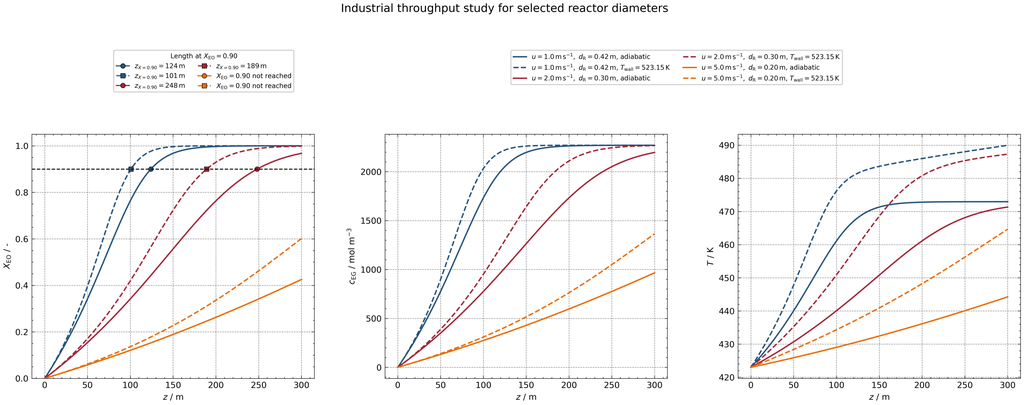

```python
# Industrial throughput study: selected diameters, flow velocities and thermal cases

from matplotlib.lines import Line2D

operating_hours = 8000                  # annual operating time, h a^-1
M_EG = 62.07e-3                         # molar mass of EG, kg mol^-1
T_wall_hot = 523.15                     # heated wall temperature, K
X_target = 0.90                         # target EO conversion, -

u_base = u                              # base fluid velocity, m s^-1
d_R_base = d_R                          # base tube diameter, m
h_wall_base = h_wall                    # base heat-transfer coefficient, J s^-1 m^-2 K^-1
T_wall_base = T_wall                    # base wall temperature, K

design_cases = {
    "Low velocity, adiabatic": {
        "u": 1.0,
        "d_R": 0.42,
        "h_wall": 0.0,
        "T_wall": T_wall_base,
        "label": r"$u = 1.0\,\mathrm{m\,s^{-1}},\ d_\mathrm{R} = 0.42\,\mathrm{m}$, adiabatic"
    },
    "Low velocity, heated wall": {
        "u": 1.0,
        "d_R": 0.42,
        "h_wall": h_wall_base,
        "T_wall": T_wall_hot,
        "label": r"$u = 1.0\,\mathrm{m\,s^{-1}},\ d_\mathrm{R} = 0.42\,\mathrm{m}$, $T_\mathrm{wall} = 523.15\,\mathrm{K}$"
    },
    "Intermediate velocity, adiabatic": {
        "u": 2.0,
        "d_R": 0.30,
        "h_wall": 0.0,
        "T_wall": T_wall_base,
        "label": r"$u = 2.0\,\mathrm{m\,s^{-1}},\ d_\mathrm{R} = 0.30\,\mathrm{m}$, adiabatic"
    },
    "Intermediate velocity, heated wall": {
        "u": 2.0,
        "d_R": 0.30,
        "h_wall": h_wall_base,
        "T_wall": T_wall_hot,
        "label": r"$u = 2.0\,\mathrm{m\,s^{-1}},\ d_\mathrm{R} = 0.30\,\mathrm{m}$, $T_\mathrm{wall} = 523.15\,\mathrm{K}$"
    },
    "High velocity, adiabatic": {
        "u": 5.0,
        "d_R": 0.20,
        "h_wall": 0.0,
        "T_wall": T_wall_base,
        "label": r"$u = 5.0\,\mathrm{m\,s^{-1}},\ d_\mathrm{R} = 0.20\,\mathrm{m}$, adiabatic"
    },
    "High velocity, heated wall": {
        "u": 5.0,
        "d_R": 0.20,
        "h_wall": h_wall_base,
        "T_wall": T_wall_hot,
        "label": r"$u = 5.0\,\mathrm{m\,s^{-1}},\ d_\mathrm{R} = 0.20\,\mathrm{m}$, $T_\mathrm{wall} = 523.15\,\mathrm{K}$"
    }
}


def solve_pftr_for_industrial_case(u_current, d_R_current, h_wall_current, T_wall_current):
    """
    Solve the PFTR model for one industrial design case.

    Parameters
    ----------
    u_current : float
        Fluid velocity, m s^-1
    d_R_current : float
        Tube diameter, m
    h_wall_current : float
        Wall heat-transfer coefficient, J s^-1 m^-2 K^-1
    T_wall_current : float
        Wall temperature, K

    Returns
    -------
    solution : OdeResult
        Numerical PFTR solution.
    """
    global u, d_R, h_wall, T_wall

    u = u_current                       # overwrite fluid velocity, m s^-1
    d_R = d_R_current                   # overwrite tube diameter, m
    h_wall = h_wall_current             # overwrite heat-transfer coefficient, J s^-1 m^-2 K^-1
    T_wall = T_wall_current             # overwrite wall temperature, K

    y0 = np.array([
        c_EO_in,                        # initial EO concentration, mol m^-3
        c_EG_in,                        # initial EG concentration, mol m^-3
        T_in                            # initial temperature, K
    ])

    solution = solve_ivp(
        fun=pftr,
        t_span=(0.0, L),
        y0=y0,
        t_eval=z_eval,
        method="Radau"
    )

    return solution


def calculate_target_length(z, X_EO, X_target):
    """
    Calculate the first reactor length at which the target conversion is reached.

    Parameters
    ----------
    z : array-like
        Axial reactor coordinate, m
    X_EO : array-like
        EO conversion profile, -
    X_target : float
        Target EO conversion, -

    Returns
    -------
    z_target : float
        First reactor length where target conversion is reached, m.
        Returns NaN if target conversion is not reached.
    """
    if np.max(X_EO) < X_target:
        return np.nan

    target_index = np.where(X_EO >= X_target)[0][0]

    if target_index == 0:
        return z[0]

    z_1 = z[target_index - 1]
    z_2 = z[target_index]

    X_1 = X_EO[target_index - 1]
    X_2 = X_EO[target_index]

    z_target = z_1 + (X_target - X_1) * (z_2 - z_1) / (X_2 - X_1)

    return z_target


industrial_design_results = {}

for case_name, case_data in design_cases.items():

    solution = solve_pftr_for_industrial_case(
        case_data["u"],
        case_data["d_R"],
        case_data["h_wall"],
        case_data["T_wall"]
    )

    z = solution.t                              # axial reactor coordinate, m
    c_EO = solution.y[0]                        # EO concentration, mol m^-3
    c_EG = solution.y[1]                        # EG concentration, mol m^-3
    T_profile = solution.y[2]                   # temperature profile, K

    c_EO_out = c_EO[-1]                         # outlet EO concentration, mol m^-3
    c_EG_out = c_EG[-1]                         # outlet EG concentration, mol m^-3

    X_EO = calculate_conversion(c_EO)           # EO conversion profile, -
    X_EO_out = X_EO[-1]                         # outlet EO conversion, -
    z_X90 = calculate_target_length(z, X_EO, X_target)

    A_cross = np.pi * case_data["d_R"]**2 / 4   # tube cross-sectional area, m^2
    V_dot = case_data["u"] * A_cross            # volume flow, m^3 s^-1
    n_dot_EG_out = c_EG_out * V_dot             # EG outlet molar flow, mol s^-1

    m_EG_year = (
        n_dot_EG_out
        * M_EG
        * operating_hours
        * 3600
        / 1000
    )                                           # annual EG production, t a^-1

    industrial_design_results[case_name] = {
        "u": case_data["u"],
        "d_R": case_data["d_R"],
        "h_wall": case_data["h_wall"],
        "T_wall": case_data["T_wall"],
        "solution": solution,
        "X_EO": X_EO,
        "X_EO_out": X_EO_out,
        "z_X90": z_X90,
        "T_max": np.max(T_profile),
        "T_out": T_profile[-1],
        "m_EG_year": m_EG_year,
        "tau": L / case_data["u"],
        "label": case_data["label"]
    }

# Restore base values

u = u_base
d_R = d_R_base
h_wall = h_wall_base
T_wall = T_wall_base

# Plot EO conversion, EG concentration and temperature profiles

fig, axes = plt.subplots(1, 3, figsize=(16, 6.5), dpi=500)

fig.suptitle(
    "Industrial throughput study for selected reactor diameters",
    fontsize=12,
    y=0.98
)

flowrate_colors = {
    1.0: ICIWcolors.CERULEAN,
    2.0: ICIWcolors.CRIMSON,
    5.0: ICIWcolors.FLAME
}

thermal_linestyles = {
    0.0: "-",
    h_wall_base: "--"
}

thermal_markers = {
    0.0: "o",
    h_wall_base: "s"
}

case_handles = []
case_labels = []

length_handles = []
length_labels = []

for case_name, result in industrial_design_results.items():

    solution = result["solution"]

    z = solution.t                      # axial reactor coordinate, m
    c_EG = solution.y[1]                # EG concentration, mol m^-3
    T = solution.y[2]                   # temperature profile, K
    X_EO = result["X_EO"]               # EO conversion, -

    color = flowrate_colors[result["u"]]
    linestyle = thermal_linestyles[result["h_wall"]]
    marker = thermal_markers[result["h_wall"]]

    line, = axes[0].plot(
        z,
        X_EO,
        color=color,
        linestyle=linestyle,
        label=result["label"]
    )

    case_handles.append(line)
    case_labels.append(result["label"])

    if not np.isnan(result["z_X90"]):

        axes[0].plot(
            result["z_X90"],
            X_target,
            marker=marker,
            markersize=5,
            markerfacecolor=color,
            markeredgecolor="black",
            markeredgewidth=0.5,
            color=color,
            linestyle="none"
        )

        length_label = rf"$z_{{X=0.90}} = {result['z_X90']:.0f}\,\mathrm{{m}}$"

    else:

        length_label = r"$X_{\mathrm{EO}} = 0.90$ not reached"

    length_handles.append(
        Line2D(
            [0],
            [0],
            marker=marker,
            color=color,
            markerfacecolor=color,
            markeredgecolor="black",
            markeredgewidth=0.5,
            linestyle=linestyle,
            linewidth=1.2,
            markersize=5
        )
    )

    length_labels.append(length_label)

    axes[1].plot(
        z,
        c_EG,
        color=color,
        linestyle=linestyle
    )

    axes[2].plot(
        z,
        T,
        color=color,
        linestyle=linestyle
    )

axes[0].axhline(
    X_target,
    color="black",
    linestyle="--",
    linewidth=1
)

axes[0].set_xlabel(r"$z$ / m")
axes[0].set_ylabel(r"$X_{\mathrm{EO}}$ / -")
axes[0].set_ylim(0, 1.05)

axes[1].set_xlabel(r"$z$ / m")
axes[1].set_ylabel(r"$c_{\mathrm{EG}}$ / mol m$^{-3}$")

axes[2].set_xlabel(r"$z$ / m")
axes[2].set_ylabel(r"$T$ / K")

for ax in axes:
    ax.grid(True)

# Both legends are placed at the same vertical height above the subplots

fig.legend(
    length_handles,
    length_labels,
    title=r"Length at $X_{\mathrm{EO}} = 0.90$",
    loc="upper center",
    ncol=2,
    fontsize=7,
    title_fontsize=7,
    bbox_to_anchor=(0.22, 0.88),
    frameon=True
)

fig.legend(
    case_handles,
    case_labels,
    loc="upper center",
    ncol=2,
    fontsize=7,
    bbox_to_anchor=(0.66, 0.88),
    frameon=True
)

# Manual spacing avoids squeezed subplots and keeps room for both legends

fig.subplots_adjust(
    left=0.06,
    right=0.98,
    bottom=0.12,
    top=0.68,
    wspace=0.25
)

plt.show()
```

**Figure 14:** $\mathrm{EO}$ conversion, $\mathrm{EG}$ concentration and temperature profiles for flow velocities of $1.0$, $2.0$ and $5.0~\mathrm{m\,s^{-1}}$ at a targeted annual production of $500~\mathrm{kt\,a^{-1}}$. The profiles compare adiabatic operation with externally heated operation at $T_\mathrm{wall}=523.15~\mathrm{K}$.

```python
# Create Markdown table for industrial design cases

markdown_table = """
**Table 15:** Performance of selected industrial reactor designs

| Case | $d_{\\mathrm{R}}\\,/\\,\\mathrm{m}$ | $u\\,/\\,\\mathrm{m\\,s^{-1}}$ | $\\tau\\,/\\,\\mathrm{s}$ | $X_{\\mathrm{EO,out}}\\,/\\,-$ | $z_{X=0.90}\\,/\\,\\mathrm{m}$ | $\\dot{m}_{\\mathrm{EG,a}}\\,/\\,\\mathrm{t\\,a^{-1}}$ | $T_{\\mathrm{max}}\\,/\\,\\mathrm{K}$ | $T_{\\mathrm{out}}\\,/\\,\\mathrm{K}$ |
| --- | ---: | ---: | ---: | ---: | ---: | ---: | ---: | ---: |
"""

for case_name, result in industrial_design_results.items():

    if np.isnan(result["z_X90"]):
        z_X90_text = "not reached"
    else:
        z_X90_text = f"{result['z_X90']:.1f}"

    markdown_table += (
        f"| {case_name} | "
        f"{result['d_R']:.2f} | "
        f"{result['u']:.1f} | "
        f"{result['tau']:.1f} | "
        f"{result['X_EO_out']:.4f} | "
        f"{z_X90_text} | "
        f"{result['m_EG_year']:.1f} | "
        f"{result['T_max']:.2f} | "
        f"{result['T_out']:.2f} |\n"
    )

display(Markdown(markdown_table))
```

**Table 15:** Performance of selected industrial reactor designs

| Case | $d_{\mathrm{R}}\,/\,\mathrm{m}$ | $u\,/\,\mathrm{m\,s^{-1}}$ | $\tau\,/\,\mathrm{s}$ | $X_{\mathrm{EO,out}}\,/\,-$ | $z_{X=0.90}\,/\,\mathrm{m}$ | $\dot{m}_{\mathrm{EG,a}}\,/\,\mathrm{t\,a^{-1}}$ | $T_{\mathrm{max}}\,/\,\mathrm{K}$ | $T_{\mathrm{out}}\,/\,\mathrm{K}$ |
| --- | --- | --- | --- | --- | --- | --- | --- | --- |
| Low velocity, adiabatic | 0.42 | 1.0 | 300.0 | 1.0000 | 124.1 | 562184.9 | 472.95 | 472.95 |
| Low velocity, heated wall | 0.42 | 1.0 | 300.0 | 1.0000 | 100.9 | 562197.0 | 489.97 | 489.97 |
| Intermediate velocity, adiabatic | 0.30 | 2.0 | 150.0 | 0.9677 | 248.2 | 555149.5 | 471.34 | 471.34 |
| Intermediate velocity, heated wall | 0.30 | 2.0 | 150.0 | 0.9985 | 189.2 | 572832.6 | 487.28 | 487.28 |
| High velocity, adiabatic | 0.20 | 5.0 | 60.0 | 0.4255 | not reached | 271198.9 | 444.25 | 444.25 |
| High velocity, heated wall | 0.20 | 5.0 | 60.0 | 0.6014 | not reached | 383366.3 | 464.67 | 464.67 |

Figure 14 and Table 15 show the performance of the selected industrial reactor designs for the target production of $500\,000~\mathrm{t\,a^{-1}}$. The comparison includes adiabatic operation and externally heated operation with $T_\mathrm{wall}=523.15~\mathrm{K}$. As already observed in Chapter 5.1, external heating improves the reactor performance because the additional heat input increases the reactor temperature and therefore accelerates the temperature-dependent reaction rate.

For the low-velocity case with $u=1.0~\mathrm{m\,s^{-1}}$ and $d_\mathrm{R}=0.42~\mathrm{m}$, both thermal operating modes reach complete $\mathrm{EO}$ conversion. In the adiabatic case, the target conversion of $X_{\mathrm{EO}}=0.90$ is reached after $124.1~\mathrm{m}$. With external heating, the required length decreases to $100.9~\mathrm{m}$. The annual $\mathrm{EG}$ production is about $562\,000~\mathrm{t\,a^{-1}}$ in both cases and therefore slightly above the target value. The maximum temperature increases from $472.95~\mathrm{K}$ in the adiabatic case to $489.97~\mathrm{K}$ in the heated-wall case. Therefore, the reactor can be built with readily available stainless steel [4].

For the intermediate-velocity case with $u=2.0~\mathrm{m\,s^{-1}}$ and $d_\mathrm{R}=0.30~\mathrm{m}$, the required conversion is also achieved. Under adiabatic conditions, the outlet conversion is $X_{\mathrm{EO},out}=0.9677$, and the target conversion is reached after $248.2~\mathrm{m}$. With external heating, the conversion  
increases to $X_{\mathrm{EO},out}=0.9985$, and the required length decreases to $189.2~\mathrm{m}$. The annual production is $555\,149.5~\mathrm{t\,a^{-1}}$ for the adiabatic case and $572\,832.6~\mathrm{t\,a^{-1}}$ for the heated-wall case. The maximum temperatures are $471.34~\mathrm{K}$ and $487.28~\mathrm{K}$, respectively.

The high-velocity case with $u=5.0~\mathrm{m\,s^{-1}}$ and $d_\mathrm{R}=0.20~\mathrm{m}$ does not satisfy the conversion target. Under adiabatic conditions, only $X_{\mathrm{EO},out}=0.4255$ is reached. Even with external heating, the conversion only increases to $X_{\mathrm{EO},out}=0.6014$. Therefore, the target conversion of $X_{\mathrm{EO}}=0.90$ is not reached within the reactor length of $300~\mathrm{m}$. Although this case increases the flow velocity, the residence time is only $60~\mathrm{s}$, which is too short for sufficient $\mathrm{EO}$ conversion.

Overall, the results show that increasing the tube diameter can increase the throughput to an industrially relevant scale. However, the residence time remains the limiting factor for conversion. The low-velocity and intermediate-velocity cases both reach the required conversion and production target, while the high-velocity case fails because the residence time is too short.

From a design perspective, the low-velocity case is the most suitable option in both thermal operating modes. With external heating, the target conversion is reached after only $100.9~\mathrm{m}$, which could reduce the required reactor length and therefore lower capital costs, although the larger tube diameter must still be considered. However, the adiabatic low-velocity case is also highly suitable because it reaches the target conversion and the required production capacity without external heat input. Therefore, the main takeaway is that the low-velocity design provides sufficient residence time and robust conversion, while adiabatic operation may be preferred from an operating-cost perspective because no additional heating is required. Heating the reactor wall to $523.15~\mathrm{K}$ would steam at pressures above $40~\mathrm{bar}$ which is typically not available in industrial plants. [5]

It should be noted that effects caused by scaling the tube diameter from $0.03~\mathrm{m}$ to up to $0.42~\mathrm{m}$ are neglected in this simplified model. In reality, such a scale-up can influence fluid flow, radial temperature gradients, mixing behaviour and heat-transfer characteristics. Therefore, the selected large-diameter cases should be interpreted as simplified design estimates. A more detailed reactor design would require additional analysis of flow regime, radial heat transfer and mechanical feasibility.

### Design potential of the selected PFTR

After selecting the final tube diameter, the design space is investigated in more detail. The tube diameter is kept constant at the selected value of $d_\mathrm{R}=0.42~\mathrm{m}$, while the fluid velocity and reactor length are varied. This allows the potential for higher throughput and higher $\mathrm{EO}$ conversion to be evaluated.

The annual $\mathrm{EG}$ production is used as the heatmap value, while conversion contours indicate the reactor length required to reach different outlet conversions. In addition, grid-based optimum points are determined for target conversions of 90%, 95% and 99%. These points represent the shortest reactor length on the investigated grid that still fulfills the required annual production and the respective conversion target.

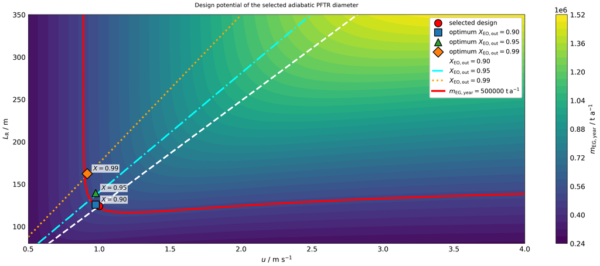

**Table 16:** Grid-based optimum design points for different target conversions.

| target conversion / - | fluid velocity / m s⁻¹ | reactor length / m | outlet conversion / - | EG production / t a⁻¹ |
| --- | --- | --- | --- | --- |
| 0.9 | 0.975 | 125.8 | 0.9184 | 503175 |
| 0.95 | 0.975 | 139.5 | 0.9558 | 523702 |
| 0.99 | 0.915 | 162.4 | 0.9912 | 510027 |

```python
# Heatmap of design potential for the selected adiabatic PFTR diameter
# Optimum points are determined for 90%, 95% and 99% EO conversion


target_production = 500000.0          # annual EG production target, t a^-1
operating_hours = 8000                # annual operating time, h a^-1
M_EG = 62.07e-3                       # molar mass of EG, kg mol^-1

d_R_selected = 0.42                   # selected tube diameter, m
u_selected = 1.0                      # selected fluid velocity, m s^-1
L_selected = 124.1                    # selected minimum reactor length, m

h_wall_selected = 0.0                 # adiabatic operation, J s^-1 m^-2 K^-1
T_wall_selected = T_wall              # wall temperature placeholder, K

u_base = u
d_R_base = d_R
h_wall_base = h_wall
T_wall_base = T_wall
L_base = L

u_grid = np.linspace(0.5, 4.0, 60)    # fluid velocity grid, m s^-1
L_grid = np.linspace(80.0, 350.0, 60) # reactor length grid, m

U, L_mesh = np.meshgrid(u_grid, L_grid)

X_EO_out_map = np.zeros_like(U)
m_EG_year_map = np.zeros_like(U)


def solve_pftr_design_potential(u_current, L_current):
    """Solve the adiabatic PFTR for one velocity-length design point."""
    global u, d_R, h_wall, T_wall

    u = u_current
    d_R = d_R_selected
    h_wall = h_wall_selected
    T_wall = T_wall_selected

    y0 = np.array([
        c_EO_in,                      # mol m^-3
        c_EG_in,                      # mol m^-3
        T_in                          # K
    ])

    solution = solve_ivp(
        fun=pftr,
        t_span=(0.0, L_current),
        y0=y0,
        t_eval=np.linspace(0.0, L_current, 300),
        method="Radau"
    )

    return solution


# Calculate heatmap data
for i in range(L_mesh.shape[0]):
    for j in range(U.shape[1]):

        u_current = U[i, j]
        L_current = L_mesh[i, j]

        solution = solve_pftr_design_potential(u_current, L_current)

        c_EO_out = solution.y[0, -1]
        c_EG_out = solution.y[1, -1]

        X_EO_out = calculate_conversion(c_EO_out)

        A_cross = np.pi * d_R_selected**2 / 4        # m^2
        V_dot = u_current * A_cross                  # m^3 s^-1
        n_dot_EG_out = c_EG_out * V_dot              # mol s^-1

        m_EG_year = (
            n_dot_EG_out
            * M_EG
            * operating_hours
            * 3600
            / 1000
        )                                            # t a^-1

        X_EO_out_map[i, j] = X_EO_out
        m_EG_year_map[i, j] = m_EG_year


# Restore base values
u = u_base
d_R = d_R_base
h_wall = h_wall_base
T_wall = T_wall_base
L = L_base


# Find grid-based optimum points for selected conversion targets
conversion_targets = [0.90, 0.95, 0.99]
optimum_points = []

for X_target in conversion_targets:

    feasible_mask = (
        (X_EO_out_map >= X_target)
        & (m_EG_year_map >= target_production)
    )

    if np.any(feasible_mask):
        feasible_indices = np.where(feasible_mask)

        feasible_L = L_mesh[feasible_indices]
        feasible_X = X_EO_out_map[feasible_indices]
        feasible_m = m_EG_year_map[feasible_indices]
        feasible_u = U[feasible_indices]

        # First minimize reactor length
        L_min = np.min(feasible_L)

        # Then choose the point closest to the target conversion
        same_L_mask = np.isclose(feasible_L, L_min)
        X_difference = np.abs(feasible_X[same_L_mask] - X_target)
        best_local_index = np.argmin(X_difference)

        u_candidates = feasible_u[same_L_mask]
        L_candidates = feasible_L[same_L_mask]
        X_candidates = feasible_X[same_L_mask]
        m_candidates = feasible_m[same_L_mask]

        optimum_points.append({
            "X_target / -": X_target,
            "u_opt / m s^-1": u_candidates[best_local_index],
            "L_opt / m": L_candidates[best_local_index],
            "X_EO_out / -": X_candidates[best_local_index],
            "m_EG_year / t a^-1": m_candidates[best_local_index]
        })

optimum_table = pd.DataFrame(optimum_points)


# Plot heatmap
fig, ax = plt.subplots(figsize=(12, 5), dpi=500)

heatmap = ax.contourf(
    U,
    L_mesh,
    m_EG_year_map,
    levels=30,
    cmap="viridis"
)

cbar = plt.colorbar(heatmap, ax=ax)
cbar.set_label(r"$m_{\mathrm{EG,year}}$ / t a$^{-1}$")

# Conversion contours without direct labels to avoid overlap
conversion_colors = ["white", "cyan", "orange"]
conversion_linestyles = ["--", "-.", ":"]

conversion_contours = ax.contour(
    U,
    L_mesh,
    X_EO_out_map,
    levels=conversion_targets,
    colors=conversion_colors,
    linewidths=2.2,
    linestyles=conversion_linestyles
)

# Production target contour
production_contour = ax.contour(
    U,
    L_mesh,
    m_EG_year_map,
    levels=[target_production],
    colors="red",
    linewidths=2.5
)

# Mark selected final design
ax.scatter(
    u_selected,
    L_selected,
    marker="o",
    s=90,
    edgecolor="black",
    facecolor="red",
    zorder=6,
    label="selected design"
)

# Mark optimum points
optimum_markers = ["s", "^", "D"]
optimum_colors = ["tab:blue", "tab:green", "tab:orange"]

for point, marker, color in zip(optimum_points, optimum_markers, optimum_colors):
    ax.scatter(
        point["u_opt / m s^-1"],
        point["L_opt / m"],
        marker=marker,
        s=90,
        edgecolor="black",
        facecolor=color,
        zorder=7,
        label=rf"optimum $X_{{\mathrm{{EO,out}}}}={point['X_target / -']:.2f}$"
    )

    ax.text(
        point["u_opt / m s^-1"] + 0.04,
        point["L_opt / m"] + 4,
        rf"$X={point['X_target / -']:.2f}$",
        fontsize=8,
        color="black",
        bbox=dict(facecolor="white", edgecolor="none", alpha=0.75, pad=1.5)
    )

# Add conversion and production contours to the legend
conversion_proxies = [
    plt.Line2D(
        [0],
        [0],
        color=color,
        linestyle=linestyle,
        linewidth=2.2,
        label=rf"$X_{{\mathrm{{EO,out}}}}={X_target:.2f}$"
    )
    for color, linestyle, X_target in zip(
        conversion_colors,
        conversion_linestyles,
        conversion_targets
    )
]

production_proxy = plt.Line2D(
    [0],
    [0],
    color="red",
    linewidth=2.5,
    label=r"$m_{\mathrm{EG,year}}=500000~\mathrm{t\,a^{-1}}$"
)

handles, labels = ax.get_legend_handles_labels()
handles.extend(conversion_proxies)
handles.append(production_proxy)

ax.set_title("Design potential of the selected adiabatic PFTR diameter")
ax.set_xlabel(r"$u$ / m s$^{-1}$")
ax.set_ylabel(r"$L_\mathrm{R}$ / m")
ax.legend(handles=handles, loc="upper right", fontsize=8)

plt.tight_layout()
plt.show()


# Display optimum design table with Markdown-compatible labels
display_table = optimum_table.copy()

display_table = display_table.round({
    "X_target / -": 2,
    "u_opt / m s^-1": 3,
    "L_opt / m": 1,
    "X_EO_out / -": 4,
    "m_EG_year / t a^-1": 1
})

display_table = display_table.rename(columns={
    "X_target / -": "target conversion / -",
    "u_opt / m s^-1": "fluid velocity / m s⁻¹",
    "L_opt / m": "reactor length / m",
    "X_EO_out / -": "outlet conversion / -",
    "m_EG_year / t a^-1": "EG production / t a⁻¹"
})

display(Markdown("**Table 16:** Grid-based optimum design points for different target conversions."))
display(Markdown(display_table.to_markdown(index=False)))
```

```python
# Display optimum design table with clean Markdown-compatible labels
display_table = optimum_table.copy()

display_table = display_table.round({
    "X_target / -": 2,
    "u_opt / m s^-1": 3,
    "L_opt / m": 1,
    "X_EO_out / -": 4,
    "m_EG_year / t a^-1": 1
})

display_table = display_table.rename(columns={
    "X_target / -": "target conversion / -",
    "u_opt / m s^-1": "fluid velocity / m s⁻¹",
    "L_opt / m": "reactor length / m",
    "X_EO_out / -": "outlet conversion / -",
    "m_EG_year / t a^-1": "EG production / t a⁻¹"
})

display(Markdown("**Table 16:** Grid-based optimum design points for different target conversions."))
display(Markdown(display_table.to_markdown(index=False)))
```

**Table 16:** Grid-based optimum design points for different target conversions.

| target conversion / - | fluid velocity / m s⁻¹ | reactor length / m | outlet conversion / - | EG production / t a⁻¹ |
| --- | --- | --- | --- | --- |
| 0.9 | 0.975 | 125.8 | 0.9184 | 503175 |
| 0.95 | 0.975 | 139.5 | 0.9558 | 523702 |
| 0.99 | 0.915 | 162.4 | 0.9912 | 510027 |

The heatmap shows that the annual $\mathrm{EG}$ production increases mainly with increasing fluid velocity. This is caused by the higher volumetric throughput through the fixed tube diameter. However, increasing the fluid velocity also reduces the residence time in the reactor. Therefore, higher velocities require longer reactor lengths to reach the same $\mathrm{EO}$ outlet conversion.

The red contour represents the required annual production of $500000~\mathrm{t\,a^{-1}}$. Combinations below this line do not reach the production target, while combinations above this line exceed it. The grid-based optimum points are located close to the region where the production target and the respective conversion target are fulfilled with minimum reactor length.

The selected final design is close to the optimum point for 90% conversion. This confirms that the chosen design is a reasonable minimum design for the required conversion and production target. If a higher conversion of 95% or 99% is required, the reactor length would have to be increased. Therefore, the heatmap supports the final design choice and also shows the additional reactor length required for higher conversion targets.

The final reactor design and operation is summarized in table 17:

**Table 17:** Selected final reactor design and operating parameters.

| Quantity | Selected value |
| --- | --- |
| Operating mode | Adiabatic tubular reactor |
| $\mathrm{EO}$ inlet concentration | $2.27 \cdot 10^3~\mathrm{mol\,m^{-3}}$ |
| $\mathrm{EG}$ inlet concentration | $0~\mathrm{mol\,m^{-3}}$ |
| Inlet temperature | $423~\mathrm{K}$ |
| minimum required Reactor Length for 90% $\mathrm{EO}$ conversion | $124.1~\mathrm{m}$ |
| Tube diameter | $0.42~\mathrm{m}$ |
| Fluid velocity | $1.0~\mathrm{m\,s^{-1}}$ |
| Residence time | $124.1~\mathrm{s}$ |
| Annual $\mathrm{EG}$ production | $562185~\mathrm{t\,a^{-1}}$ |

#### Comparison of reactor design to literature

The selected low-velocity reactor design is in good agreement with the reactor dimensions reported by Batiha [6] for the non-catalytic hydrolysis of $\mathrm{EO}$. Batiha describes the hydrolysis reactor as a tubular adiabatic U-shaped reactor with a length of $150~\mathrm{m}$ and a diameter of $0.53~\mathrm{m}$. In this work, the low-velocity case uses a slightly smaller diameter of $0.42~\mathrm{m}$, which is still in the same order of magnitude.

For the adiabatic low-velocity case, the target conversion of $X_{\mathrm{EO}}=0.90$ is reached after $124.1~\mathrm{m}$. This is comparable to the reactor length of $150~\mathrm{m}$ reported by Batiha [6]. With external heating, the required length decreases further to $100.9~\mathrm{m}$. Therefore, the selected low-velocity design appears plausible for the considered reaction system.

The residence time can additionally be compared with the patent US3922314A [7]. In the described process, a residence time of $600~\mathrm{s}$ is reported for an $\mathrm{EO}$ conversion of $99.9\%$. In this work, the low-velocity adiabatic case has a residence time of $300~\mathrm{s}$ and reaches complete $\mathrm{EO}$ conversion at the reactor outlet. The shorter residence time is plausible because the present model is based on an ideal plug-flow reactor and a simplified reaction system, while the patent describes a real process. Nevertheless, both results show that high $\mathrm{EO}$ conversion requires sufficiently long residence time.

The comparison also supports the conclusion that the high-velocity case is not suitable. Although its tube diameter is smaller, the residence time is only $60~\mathrm{s}$ and the required conversion is not reached. Thus, the literature comparison confirms that sufficient reactor length and residence time are essential for the non-catalytic hydrolysis of $\mathrm{EO}$ to $\mathrm{EG}$.

### 5.3 Comparison between PFTR and a Batch STR

For comparison, the selected PFTR design is transferred to an ideal batch stirred tank reactor. The same feed composition, inlet temperature, adiabatic operation and annual EG production are assumed. Since the selected PFTR is operated with a velocity of $1.0\,\mathrm{m\,s^{-1}}$, the minimum required reactor length of 124.1 m corresponds to a residence time of 124.1 s. Therefore, the minimum reaction time for the batch STR is set equal to this value.

\begin{equation} t_{\mathrm{reaction}} = 124.1\,\mathrm{s} \tag{87} \end{equation}

In addition to the reaction time, a downtime of 20 min is assumed between two batch cycles. This downtime includes filling, emptying and preparation of the reactor for the next cycle.

\begin{equation} t_{\mathrm{downtime}} = 20\,\mathrm{min} = 1200\,\mathrm{s} \tag{88} \end{equation}

The total cycle time of one batch is therefore:

\begin{equation} t_{\mathrm{cycle}} = t_{\mathrm{reaction}} + t_{\mathrm{downtime}} = 124.1\,\mathrm{s} + 1200\,\mathrm{s} = 1324.1\,\mathrm{s} \tag{89} \end{equation}

For the same annual production as the selected PFTR case, the equivalent volumetric throughput is taken from the final reactor design:

\begin{equation} \dot{V} = 0.139\,\mathrm{m^3\,s^{-1}} \tag{90} \end{equation}

The required working volume of one batch reactor is calculated from the equivalent throughput and the total cycle time:

\begin{equation} V_{\mathrm{batch}} = \dot{V} \cdot t_{\mathrm{cycle}} = 0.139\,\mathrm{m^3\,s^{-1}} \cdot 1324.1\,\mathrm{s} = 184\,\mathrm{m^3} \tag{91} \end{equation}

To estimate the vessel dimensions, a cylindrical stirred tank with a height-to-diameter ratio of 1.5 is assumed:

\begin{equation} \frac{H}{D} = 1.5 \tag{92} \end{equation}

The vessel volume is calculated by:

\begin{equation} V_{\mathrm{batch}} = \frac{\pi D^2}{4}H \tag{93} \end{equation}

With $H=1.5D$, the required vessel diameter becomes:

\begin{equation} D = \left( \frac{4V_{\mathrm{batch}}}{1.5\pi} \right)^{1/3} = 5.4\,\mathrm{m} \tag{94} \end{equation}

The corresponding liquid height is:

\begin{equation} H = 1.5D = 8.1\,\mathrm{m} \tag{95} \end{equation}

**Table 18:** Estimated batch stirred tank reactor design for the same annual production as the selected PFTR case.

| Quantity | Value |
| --- | --- |
| Operating mode | Adiabatic batch STR |
| Annual EG production | 562185 t a⁻¹ |
| Equivalent volumetric throughput | 0.139 m³ s⁻¹ |
| Reaction time | 124.1 s |
| Downtime between cycles | 1200 s |
| Total cycle time | 1324.1 s |
| Required working volume | 184 m³ |
| Assumed vessel geometry | Cylindrical tank, H/D = 1.5 |
| Estimated tank diameter | 5.4 m |
| Estimated liquid height | 8.1 m |
| EO outlet conversion | 0.90 |

The comparison shows that the batch STR would require a much larger reactor volume than the selected PFTR. Although the reaction itself only requires 124.1 s to reach the target conversion, the additional downtime of 20 min strongly increases the required working volume. Therefore, a single batch STR for the same annual production would still be large. This supports the conclusion that the continuous PFTR is more suitable for large-scale EG production.

## 6. Conclusion

In this assignment, the non-catalytic hydrolysis of $\mathrm{EO}$ to $\mathrm{EG}$ was investigated in an ideal plug-flow tubular reactor. The model included the material balances for $\mathrm{EO}$ and $\mathrm{EG}$ as well as the energy balance for adiabatic, polytropic and externally heated operation. Since $\mathrm{EO}$ and $\mathrm{EG}$ are related by a 1:1 stoichiometry, the $\mathrm{EG}$ yield corresponds directly to the $\mathrm{EO}$ conversion. Therefore, the evaluation focused mainly on the $\mathrm{EO}$ conversion.

The parameter studies showed that the reactor performance is mainly governed by the interaction between reaction kinetics and heat management. Higher inlet or wall temperatures increase the reaction rate and therefore improve the conversion. An increased $\mathrm{EO}$ inlet concentration also leads to higher heat generation, which accelerates the reaction in the adiabatic and polytropic cases. In contrast, an increased fluid velocity reduces the residence time and therefore lowers the conversion, even if heat transfer may be improved. The dimensionless analysis confirmed this behavior: the Damköhler number describes the ratio between residence time and reaction rate, while the Stanton number describes the influence of heat transfer to the reactor wall.

For the industrial production target, the low-velocity tubular reactor was identified as the most suitable design. The selected reactor uses a tube diameter of $0.42~\mathrm{m}$ and a fluid velocity of $1.0~\mathrm{m,s^{-1}}$. A minimum reactor length of $124.1~\mathrm{m}$ is required to reach the target conversion of $X_\mathrm{EO}=0.90$. With this design, an annual $\mathrm{EG}$ production of $562185~\mathrm{t a^{-1}}$ can be achieved, which exceeds the required production capacity. The design is also plausible compared with literature data, since the required reactor length and tube diameter are in the same order of magnitude as reported industrial reactor dimensions.

The comparison with an ideal batch stirred tank reactor showed that batch operation is less attractive for this large-scale production case. Although the reaction time itself is only $124.1~\mathrm{s}$, the required working volume increases strongly when the downtime between batch cycles is included. Even with a downtime of only 20 min, the required batch volume is approximately $184~\mathrm{m^3}$. This is much larger than the corresponding PFTR reaction volume for the same conversion target. Therefore, continuous PFTR operation is more suitable for large-scale $\mathrm{EG}$ production.

Overall, the PFTR provides high conversion, continuous production and a compact reactor volume compared with a batch STR. However, the results are based on an idealized reactor model. For a final industrial design, additional aspects such as pressure drop, wall thickness, mixing limitations, safety aspects of $\mathrm{EO}$ handling, side-product formation and detailed heat-transfer design would have to be considered.

## Literature

| No. | Source |
| --- | --- |
| [1] | Güttel, R.; Turek, T. *Chemische Reaktionstechnik*. Springer Spektrum, Berlin, Heidelberg, 2021. DOI: 10.1007/978-3-662-63150-8. |
| [2] | van Hal, J. W.; Ledford, J. S.; Zhang, X. Investigation of three types of catalysts for the hydration of ethylene oxide (EO) to monoethylene glycol (MEG). *Catalysis Today* **2007**, *123*, 310–315. D… |
| [3] | Falcke, H.; Holbrook, S.; Clenahan, I.; et al. *Best Available Techniques (BAT) Reference Document for the Production of Large Volume Organic Chemicals*. Publications Office of the European Union, Lux… |
| [4] | thyssenkrupp Materials (UK). *Stainless Steel 304 1.4301 Data Sheet*. Accessed 17 June 2026. Available online: https://www.thyssenkrupp-materials.co.uk/stainless-steel-304-14301.html |
| [5] | Michigan Technological University. *Steam Tables*. Available online: https://pages.mtu.edu/~tbco/cm3230/steamtables.pdf |
| [6] | Batiha, M. M. Dynamic Modelling of the Non-Catalytic Process of Ethylene Oxide Hydrolysis. *Journal of Science and Technology* **2004**, *9*(1). DOI: 10.20428/jst.v9i1.101. Available online: https://j… |
| [7] | Pluss, L.; Baysinger, F. R. *Process for the Preparation of Ethylene Glycol*. US Patent US3922314A, 1975. Available online: https://patents.google.com/patent/US3922314A/en |

## Contribution

All peers equally contributed to the project.

## AI Use and Reflection

### Tools Used

The following AI tools were used during the preparation of this assignment:

| Tool | Model / Version | Date of Use | Purpose |
| --- | --- | --- | --- |
| ChatGPT | 5.5 Thinking | June / 2026 | Code implementation, spell- and grammar checks |

### Areas of Use

AI tools were used for the following subtasks:

| Area | Use of AI | Own follow-up / verification |
| --- | --- | --- |
| Code implementation | after reactor model was developed, the necessary balance equations and the initial value problem were implemented | Verification using calculated mass- and energy balance (as in chapter 3.5) |
| Language editing | Grammar, readability and typos | proofreading after AI correction |
| Markdown editing | After writing markdown, AI was used to implement e.g. LaTeX notation | proofreading after AI correction |

### Prompting Strategy

For language and Markdown editing, the scientific content was first written manually. This included the reasoning, descriptions of trends, interpretation of results and the general structure of the text. Formal parts such as equations were also written down manually, but not always in final notation. The text was then handed to an AI tool to improve the Markdown formatting, implement proper LaTeX notation, and check grammar and spelling. The corrected Markdown output was afterwards proof-read manually and only added to the project when it was considered suitable.

The prompting strategy for code implementation was realized differently. After the Markdown description of the PFTR or batch STR model was completed, this model description was handed to the AI tool. Based on this, specific prompts were used to obtain a suitable Python implementation. If questions occurred during the implementation, for example regarding data handling or the use of additional packages such as the `brentq` root solver, the AI tool was asked for clarification. The answers were checked for validity using independent sources such as the official package documentation. The implemented code was then manually checked for mathematical correctness and consistency with the model equations before it was added to the report.

A typical prompt for code implementation was structured as follows:

> [Markdown of the model presented here]

> Implement this model using the stated parameters. In this case, the inlet temperature is varied and the investigated values are already provided in the Markdown description. Plot the concentration profile, temperature profile and conversion profile. Mark the maximum temperature and present its value in the plot. Additionally, create Table X containing the outlet conversion, maximum temperature and conversion after 150 m.

### Used Chats for this project (Can also be found in the supporting information)

- [Markdown](https://chatgpt.com/share/6a324b96-4d68-83eb-98cd-addcb88be537)
- [Code Implementation](https://chatgpt.com/share/6a324b88-0268-83eb-b189-e70e155342fc)

# 7. Appendix

## 7.1 Python packages and function documentation

All Python packages and functions used in the program are listed below. The packages are used for numerical calculations, solving differential equations, creating plots, formatting tables and applying the selected plotting style.

#### Used Python packages

| Package / function | Purpose in the program |
| --- | --- |
| `os` | Handles file paths, mainly for locating the custom plotting style package. |
| `numpy` as `np` | Provides numerical arrays, mathematical operations, interpolation and grid generation. |
| `pandas` as `pd` | Creates and formats result tables. |
| `matplotlib.pyplot` as `plt` | Creates concentration, temperature, conversion and heatmap plots. |
| `matplotlib` as `mpl` | Provides additional Matplotlib configuration options. |
| `ListedColormap` from `matplotlib.colors` | Defines custom colormaps for plots. |
| `Line2D` from `matplotlib.lines` | Creates custom legend entries. |
| `solve_ivp` from `scipy.integrate` | Solves the PFTR ordinary differential equation system. |
| `brentq` from `scipy.optimize` | Finds roots, for example the velocity at which a target conversion is reached. |
| `Markdown` and `display` from `IPython.display` | Displays Markdown captions and tables inside the notebook. |
| `ICIW_Plots` | Loads the custom ICIW plotting style. |
| `ICIW_Plots.colors` as `ICIWcolors` | Provides custom color definitions for plots. |

#### Implemented Python functions

| Function | Purpose |
| --- | --- |
| `kinetics(c_EO, T)` | Calculates the pseudo-first-order reaction rate of EO hydrolysis. |
| `pftr(z, y)` | Defines the PFTR mass and energy balance equations. |
| `calculate_conversion(c_EO, c_EO_0=c_EO_in)` | Calculates the EO conversion from the EO concentration. |
| `solve_pftr_for_design_case(u_current, h_wall_current, T_wall_current)` | Solves the PFTR model for a selected velocity and thermal case. |
| `calculate_outlet_conversion_for_case(u_current, h_wall_current, T_wall_current)` | Calculates the outlet EO conversion for a selected velocity and thermal case. |
| `solve_pftr_for_industrial_case(u_current, d_R_current, h_wall_current, T_wall_current)` | Solves the PFTR model for one industrial design case with varied velocity, diameter and thermal operation. |
| `calculate_target_length(z, X_EO, X_target)` | Calculates the first reactor length at which a target EO conversion is reached. |
| `solve_pftr_design_potential(u_current, L_current)` | Solves the adiabatic PFTR for one velocity-length design point in the design-potential heatmap. |

#### Function documentation

##### `kinetics(c_EO, T)`

This function calculates the reaction rate using the pseudo-first-order kinetic expression. The temperature dependence of the rate constant is described by the Arrhenius equation.

| Argument | Description |
| --- | --- |
| `c_EO` | EO concentration in mol m⁻³ |
| `T` | Reactor temperature in K |

| Return value | Description |
| --- | --- |
| `r` | Reaction rate in mol m⁻³ s⁻¹ |

##### `pftr(z, y)`

This function defines the ordinary differential equation system for the PFTR. The state vector contains the EO concentration, EG concentration and temperature. The function returns the axial derivatives of these quantities.

| Argument | Description |
| --- | --- |
| `z` | Axial reactor coordinate in m |
| `y` | State vector containing EO concentration, EG concentration and temperature |

| Return value | Description |
| --- | --- |
| `[dc_EO_dz, dc_EG_dz, dT_dz]` | Axial derivatives of EO concentration, EG concentration and temperature |

##### `calculate_conversion(c_EO, c_EO_0=c_EO_in)`

This function calculates the EO conversion from the current EO concentration and the inlet EO concentration.

| Argument | Description |
| --- | --- |
| `c_EO` | EO concentration in mol m⁻³ |
| `c_EO_0` | Initial EO concentration in mol m⁻³ |

| Return value | Description |
| --- | --- |
| `X_EO` | EO conversion |

##### `solve_pftr_for_design_case(u_current, h_wall_current, T_wall_current)`

This function solves the PFTR model for a selected flow velocity and thermal operation. It is mainly used for comparing different thermal cases, such as adiabatic and heated-wall operation.

| Argument | Description |
| --- | --- |
| `u_current` | Fluid velocity in m s⁻¹ |
| `h_wall_current` | Wall heat-transfer coefficient in J s⁻¹ m⁻² K⁻¹ |
| `T_wall_current` | Wall temperature in K |

| Return value | Description |
| --- | --- |
| `solution` | Numerical PFTR solution from `solve_ivp` |

##### `calculate_outlet_conversion_for_case(u_current, h_wall_current, T_wall_current)`

This function solves the PFTR for a selected case and returns only the outlet conversion. It is useful for root-finding calculations and velocity studies.

| Argument | Description |
| --- | --- |
| `u_current` | Fluid velocity in m s⁻¹ |
| `h_wall_current` | Wall heat-transfer coefficient in J s⁻¹ m⁻² K⁻¹ |
| `T_wall_current` | Wall temperature in K |

| Return value | Description |
| --- | --- |
| `X_EO_out` | EO outlet conversion |

##### `solve_pftr_for_industrial_case(u_current, d_R_current, h_wall_current, T_wall_current)`

This function solves the PFTR model for one industrial reactor design case. In contrast to the basic design-case function, the tube diameter is also varied.

| Argument | Description |
| --- | --- |
| `u_current` | Fluid velocity in m s⁻¹ |
| `d_R_current` | Tube diameter in m |
| `h_wall_current` | Wall heat-transfer coefficient in J s⁻¹ m⁻² K⁻¹ |
| `T_wall_current` | Wall temperature in K |

| Return value | Description |
| --- | --- |
| `solution` | Numerical PFTR solution from `solve_ivp` |

##### `calculate_target_length(z, X_EO, X_target)`

This function determines the first reactor length at which a selected target conversion is reached. If the target conversion is not reached in the simulated reactor length, the function returns `NaN`.

| Argument | Description |
| --- | --- |
| `z` | Axial reactor coordinate in m |
| `X_EO` | EO conversion profile |
| `X_target` | Target EO conversion |

| Return value | Description |
| --- | --- |
| `z_target` | Reactor length where the target conversion is first reached in m |

##### `solve_pftr_design_potential(u_current, L_current)`

This function solves the adiabatic PFTR for one point in the design-potential heatmap. The selected tube diameter is kept constant, while velocity and reactor length are varied.

| Argument | Description |
| --- | --- |
| `u_current` | Fluid velocity in m s⁻¹ |
| `L_current` | Reactor length in m |

| Return value | Description |
| --- | --- |
| `solution` | Numerical PFTR solution from `solve_ivp` |

#### General implementation note

The program is based on a modular structure. The reaction kinetics are calculated first, then used inside the PFTR balance function. The PFTR balance function is solved repeatedly for different operating and design cases. Additional helper functions are used to calculate conversion, target reactor length, annual EG production and grid-based optimum design points. This structure avoids repeating the full model equations in every study and makes the parameter variations easier to compare.

## 7.2 Package Versions

```python
import sys
import platform
import numpy as np
import pandas as pd
import matplotlib
import scipy

print("Python version:", sys.version)
print("Platform:", platform.platform())
print("NumPy version:", np.__version__)
print("Pandas version:", pd.__version__)
print("Matplotlib version:", matplotlib.__version__)
print("SciPy version:", scipy.__version__)

try:
    import IPython
    print("IPython version:", IPython.__version__)
except ImportError:
    print("IPython not installed")

try:
    import ICIW_Plots
    print("ICIW_Plots version:", getattr(ICIW_Plots, "__version__", "version not available"))
except ImportError:
    print("ICIW_Plots not installed")
```

```
Python version: 3.12.3 (main, Mar 23 2026, 19:04:32) [GCC 13.3.0]
Platform: Linux-6.17.0-22-generic-x86_64-with-glibc2.39
NumPy version: 2.4.6
Pandas version: 3.0.3
Matplotlib version: 3.10.9
SciPy version: 1.17.1
IPython version: 9.14.1
ICIW_Plots version: version not available
```